# УЧЕБНИК ДЛЯ ВУЗОВ

### Т. А. Павловская

# С/С++ Программирование на языке высокого уровня

Страница 000

### УЧЕБНИК / ДЛЯ ВУЗОВ Т. А. Павловская

# С/С++ Программирование на языке высокого уровня

Допущено Министерством образования Российской Федерации в качестве учебника для студентов высших учебных заведений, обучающихся по направлению «Информатика и вычислительная техника» Издательская программа 300 лучших учебников для высшей школы в честь 300-летия Санкт-Петербурга осуществляется при поддержке Министерства образования РФ

Москва • Санкт-Петербург - Нижний Новгород • Воронеж Ростов-на-Дону • Екатеринбург • Самара • Новосибирск Киев - Харьков - КротоХомиковск - Минск 2004

Страница 001

Рецензенты:

Ревунков Г. И., кандидат технических наук, доцент, декан факультета информатики и систем управления МГТУ им. Н. Э. Баумана

Варлинский Н. Н., кандидат технических наук, доцент кафедры МО ЭВМ

Санкт-Петербургского электротехнического университета

Фомичев B.C., доктор технических наук, профессор кафедры вычислительной техники

Санкт-Петербургского электротехнического университета

П12 C/C++. Программирование на языке высокого уровня / Т. А. Павловская. — СПб.: Питер, 2003. —461 с: ил.

Задача этой книги — дать краткое и четкое изложение языка C++ в соответствии со стандар том ISO/IEC 14882. Она предназначена для студентов, изучающих язык «с нуля», но будет полезна и более искушенным в программировании. Цель, которая ставилась при написании книги — дать правильное представление о возможностях языка C++ и способах их применения, толчок к даль нейшему изучению этого и других языков программирования и ключ к пониманию современных объектно-ориентированных технологий. Контрольные задания по ключевым темам представлены в 20 вариантах, и автор надеется, что преподаватели оценят проявленную о них заботу.

Страница 002

# Краткое содержание

- Страница 11 - Предисловие
- Страница 13 - Часть I. Структурное программирование
  - Страница 15 - Глава 1. Базовые средства языка C++
  - Страница 72 - Глава 2. Модульное программирование
  - Страница 102 - Глава 3. Технология создания программ
  - Страница 128 - Упражнения к части 1
- Страница 173 - Часть II. Объектно-ориентированное программирование
  - Страница 178 - Глава 4. Классы
  - Страница 200 - Глава 5. Наследование
  - Страница 211 - Глава 6. Шаблоны классов
  - Страница 222 - Глава 7. Обработка исключительных ситуаций
  - Страница 231 - Глава 8. Преобразования типов
  - Страница 241 - Глава 9. Рекомендации по программированию
  - Страница 248 - Упражнения к части 2
- Страница 263 - Часть III. Стандартная библиотека
  - Страница 265 - Глава 10. Потоковые классы
  - Страница 286 - Глава 11. Строки
  - Страница 295 - Глава 12. Контейнерные классы
  - Страница 328 - Глава 13. Итераторы и функциональные объекты
  - Страница 343 - Глава 14. Алгоритмы
  - Страница 369 - Глава 15. Средства для численных расчетов
  - Страница 378 - Глава 16. Другие средства стандартной библиотеки
  - Страница 381 - Упражнения к части III
- Страница 382 - Послесловие
- Страница 383 - Литература
- Страница 384 - Приложение 1. Операции языка C++
- Страница 387 - Приложение 2. Спецификации формата для функций семейства printf
- Страница 390 - Приложение 3. Арифметические преобразования типов
- Страница 391 - Приложение 4. Заголовочные файлы стандартной библиотеки
- Страница 394 - Приложение 5. Константы, макросы и типы данных стандартной библиотеки
- Страница 409 - Приложение 6. Функции стандартной библиотеки
- Страница 447 - Приложение 7. Таблицы кодов ASCII
- Страница 450 - Алфавитный указатель

Страница 003

# Содержание

- Страница 11 - Предисловие
- Страница 13 - Часть1. Структурное программирование
- Страница 15 - Глава 1. Базовые средства языка C++
  - Страница 15 - Состав языка
    - Страница 17 - Алфавит языка
    - Страница 18 - Идентификаторы
    - Страница 19 - Ключевые слова
    - Страница 19 - Знаки операций
    - Страница 20 - Константы
    - Страница 22 - Комментарии
  - Страница 22 - Типы данных C++
    - Страница 22 - Концепция типа данных
    - Страница 23 - Основные типы данных
    - Страница 26 - Структура программы
  - Страница 28 - Переменные и выражения
    - Страница 28 - Переменные
    - Страница 31 - Операции
    - Страница 37 - Выражения
  - Страница 38 - Базовые конструкции структурного программирования
    - Страница 40 - Оператор «выражение»
    - Страница 40 - Операторы ветвления
    - Страница 44 - Операторы цикла
    - Страница 49 - Операторы передачи управления
  - Страница 51 - Указатели и массивы
    - Страница 51 - Указатели
    - Страница 58 - Ссылки
    - Страница 58 - Массивы
  - Страница 65 - Типы данных, определяемые пользователем
    - Страница 65 - Переименование типов (typedef)
    - Страница 66 - Перечисления (enum)
    - Страница 67 - Структуры (struct)
    - Страница 69 - Объединения (union)

Страница 004

- Страница 72 - Глава 2 . Модульное программирование
  - Страница 73 - Функции
    - Страница 74 - Объявление и определение функций
    - Страница 76 - Глобальные переменные
    - Страница 76 - Возвращаемое значение
    - Страница 77 - Параметры функции
    - Страница 83 - Рекурсивные функции
    - Страница 83 - Перегрузка функций
    - Страница 85 - Шаблоны функций
    - Страница 87 - Функция main()
    - Страница 88 - Функции стандартной библиотеки
  - Страница 93 - Директивы препроцессора
    - Страница 93 - Директива #inclucle
    - Страница 94 - Директива #define
    - Страница 95 - Директивы условной компиляции
    - Страница 96 - Директива #undef
  - Страница 97 - Области действия идентификаторов
    - Страница 98 - Внешние объявления
    - Страница 99 - Поименованные области
- Страница 102 - Глава 3. Технология создания программ
  - Страница 102 - Кодирование и документирование программы
  - Страница 109 - Проектирование и тестирование программы
  - Страница 114 - Динамические структуры данных
    - Страница 115 - Линейные списки
    - Страница 119 - Стеки
    - Страница 121 - Очереди
    - Страница 122 - Бинарные деревья
    - Страница 126 - Реализация динамических структур с помощью массивов
- Страница 128 - Упражнения к части 1
  - Страница 128 - Циклические вычислительные процессы
  - Страница 136 - Одномерные массивы
  - Страница 139 - Двумерные массивы
  - Страница 142 - Одномерные и двумерные массивы
  - Страница 144 - Структуры
  - Страница 151 - Указатели
  - Страница 151 - Простейшие функции
  - Страница 151 - Функции и файлы
  - Страница 159 - Функции библиотеки для работы со строками и символами
  - Страница 165 - Шаблоны функций
  - Страница 165 - Модульное программирование
  - Страница 165 - Динамические структуры данных

Страница 005

- Страница 173 - Часть II. Объектно-ориентированное программирование
  - Страница 178 - Глава 4. Классы
    - Страница 178 - Описание класса
    - Страница 180 - Описание объектов ;
    - Страница 181 - Указатель this
    - Страница 182 - Конструкторы
      - Страница 184 - Конструктор копирования
    - Страница 185 - Статические элементы класса
      - Страница 186 - Статические поля
      - Страница 186 - Статические методы
    - Страница 187 - Дружественные функции и классы
      - Страница 187 - Дружественная функция
      - Страница 188 - Дружественный класс
    - Страница 188 - Деструкторы
    - Страница 189 - Перегрузка операций
      - Страница 190 - Перегрузка унарных операций
      - Страница 191 - Перегрузка бинарных операций
      - Страница 191 - Перегрузка операции присваивания
      - Страница 192 - Перегрузка операций new и delete
      - Страница 195 - Перегрузка операции приведения типа
      - Страница 195 - Перегрузка операции вызова функции
      - Страница 196 - Перегрузка операции индексирования
    - Страница 197 - Указатели на элементы классов
    - Страница 198 - Рекомендации по составу класса
- Страница 200 - Глава 5. Наследование
  - Страница 200 - Ключи доступа
  - Страница 201 - Простое наследование
  - Страница 205 - Виртуальные методы
    - Страница 207 - Механизм позднего связывания
    - Страница 208 - Абстрактные классы
  - Страница 208 - Множественное наследование
  - Страница 209 - Отличия структур и объединений от классов
- Страница 211 - Глава 6. Шаблоны классов
  - Страница 211 - Создание шаблонов классов
  - Страница 219 - Использование шаблонов классов
  - Страница 220 - Специализация шаблонов классов
  - Страница 221 - Достоинства и недостатки шаблонов

Страница 006

- Страница 223 - Глава 7. Обработка исключительных ситуаций
  - Страница 223 - Общий механизм обработки исключений
  - Страница 223 - Синтаксис исключений
  - Страница 225 - Перехват исключений
  - Страница 227 - Список исключений функции
  - Страница 228 - Исключения в конструкторах и деструкторах
  - Страница 229 - Иерархии исключений
- Страница 231 - Глава 8. Преобразования типов
  - Страница 231 - Операция приведения типов в стиле С
  - Страница 232 - Операция const_cast
  - Страница 232 - Операция clynamic_cast
    - Страница 233 - Повышающее преобразование
    - Страница 233 - Понижающее преобразование
    - Страница 235 - Преобразование ссылок
    - Страница 236 - Перекрестное преобразование
  - Страница 237 - Операция static_cast
  - Страница 238 - Операция reinterpret_cast
  - Страница 238 - Динамическое определение типа
- Страница 241 - Глава 9. Рекомендации по программированию
  - Страница 248 - Упражнения к части II
    - Страница 248 - Классы
      - Страница 252 - Наследование
      - Страница 260 - Шаблоны классов
- Страница 263 - Часть 3. Стандартная библиотека
  - Страница 265 - Глава 10. Потоковые классы
    - Страница 267 - Стандартные потоки
    - Страница 269 - Форматирование данных
      - Страница 269 - Флаги и форматирующие методы
      - Страница 271 - Манипуляторы
    - Страница 273 - Методы обмена с потоками
    - Страница 278 - Ошибки потоков
    - Страница 280 - Файловые потоки
    - Страница 282 - Строковые потоки
    - Страница 284 - Потоки и типы, определенные пользователем

Страница 007

- Страница 286 - Глава 11. Строки
  - Страница 287 - Конструкторы и присваивание строк
  - Страница 288 - Операции
  - Страница 288 - Функции
    - Страница 288 - Присваивание и добавление частей строк
    - Страница 289 - Преобразования строк
    - Страница 291 - Поиск подстрок
    - Страница 293 - Сравнение частей строк
    - Страница 294 - Получение характеристик строк
- Страница 295 - Глава 12. Контейнерные классы
  - Страница 297 - Последовательные контейнеры
    - Страница 299 - Векторы (vector)
    - Страница 304 - Двусторонние очереди (deque)
    - Страница 306 - Списки (list)
    - Страница 310 - Стеки (stack)
    - Страница 311 - Очереди (queue)
    - Страница 313 - Очереди с приоритетами (priority__queue)
- Страница 315 - Ассоциативные контейнеры
  - Страница 316 - Словари (тар)
  - Страница 321 - Словари с дубликатами (multimap)
  - Страница 321 - Множества (set)
  - Страница 323 - Множества с дубликатами (multiset)
  - Страница 323 - Битовые множества (bitset)
  - Страница 325 - Пример использования контейнеров
- Страница 328 - Глава 13. Итераторы и функциональные объекты
  - Страница 328 - Итераторы
    - Страница 331 - Обратные итераторы
    - Страница 332 - Итераторы вставки
    - Страница 333 - Потоковые итераторы
  - Страница 334 - Функциональные объекты
    - Страница 335 - Арифметические функциональные объекты
    - Страница 336 - Предикаты
    - Страница 337 - Отрицатели
    - Страница 337 - Связыватели
    - Страница 338 - Адаптеры указателей на функции
    - Страница 341 - Адаптеры методов

Страница 008

- Страница 343 - Глава 14. Алгоритмы
  - Страница 344 - Немодифицирующие операции с последовательностями
    - Страница 345 - adjacent_find
    - Страница 345 - count, countjf
    - Страница 346 - equal
    - Страница 346 - find, find_jf
    - Страница 347 - find_first_of
    - Страница 347 - find_end
    - Страница 347 - for_each
    - Страница 348 - mismatch
    - Страница 348 - search, search_n
  - Страница 348 - Модифицирующие операции с последовательностями
    - Страница 350- сору, copy_backward
    - Страница 351 - fill,fill_n
    - Страница 351 - generate, generate_n
    - Страница 352 - iter_swap, swap, swap_ranges
    - Страница 352 - random_shuffle
    - Страница 353 - remove, remove_jf, remove__copy, remove_copy_if
    - Страница 354 - replace, replace_jf, replace_copy, replace__copy_if
    - Страница 355 - reverse, reverse_copy
    - Страница 355 - rotate, rotate__copy
    - Страница 356 - transform
    - Страница 357 - unique, unique_copy
- Страница 357- Алгоритмы, связанные с сортировкой
  - Страница 358 - binary_search
  - Страница 359 - equal__range
  - Страница 359 - inplace_merge
  - Страница 359 - lexicographical_compare
  - Страница 360 - lower_bound, upper_bound
  - Страница 360 - max, min
  - Страница 360 - max_element, min_element
  - Страница 361 - merge
  - Страница 361 - next_permutation, prev_permutation
  - Страница 362 - nth_element
  - Страница 363 - partial__sort, partial_sort_copy
  - Страница 363 - partition, stable_partition
  - Страница 364 - sort, stable_sort
- Страница 364 - Алгоритмы работы с множествами и пирамидами
  - Страница 365 - includes
  - Страница 365 - setjntersection
  - Страница 366 - set_difference, set__symmetric_difference
  - Страница 366 - set_union
  - Страница 366 - Пример использования алгоритмов работы с множествами
  - Страница 367 - make_heap
  - Страница 368 - pop_heap
  - Страница 368 - push_heap
  - Страница 368 - sort_heap

Страница 009

- Страница 369 - Глава 15. Средства для численных расчетов
  - Страница 369 - Обобщенные численные алгоритмы
    - Страница 369 - accumulate
    - Страница 370 - inner_product
    - Страница 370 - partial_sum
    - Страница 371 - adjacent_difference
    - Страница 371 - Класс valarray
    - Страница 374 - Вспомогательные классы
- Страница 378 - Глава 16. Другие средства стандартной библиотеки
- Страница 381 - Упражнения к части III
- Страница 382 - Послесловие
- Страница 383 - Литература
- Страница 384 - Приложение 1. Операции языка C++
- Страница 387 - Приложение 2. Спецификации формата для функций семейства printf
- Страница 390 - Приложение 3. Арифметические преобразования типов
- Страница 391 - Приложение 4. Заголовочные файлы стандартной библиотеки
- Страница 394 - Приложение 5. Константы, макросы и тмпы данных стандартной библиотеки
- Страница 409 - Приложение 6. Функции стандартной библиотеки
- Страница 409 - Состав заголовочных файлов
- Страница 416 - Алфавитный перечень функций
- Страница 447 - Приложение 7. Таблицы кодов ASCII
- Страница 450 - Алфавитный указатель

Страница 010

# Предисловие

Задача этой книги — дать краткое и четкое изложение языка C++ в соответствии со стандартом ISO/IEC 14882 (1998) без легковесности и фрагментарности серии «Для чайников» и без пространных рассуждений о нюансах, важность которых становится очевидной только после приобретения опыта программирования. Книга предназначена для студентов, изучающих язык «с нуля», но будет полезна и более искушенным в программировании. Можно рассматривать ее как конспект лекций или большую шпаргалку. **Книга не претендует** на полноту изложения материала, для этого существуют справочники, документация и контекстная помощь. Цель, которая ставилась при её написании, — дать правильное представление о возможностях языка C++ и способах их применения, а также толчок к дальнейшему изучению этого и других языков программирования. **Кроме конструкций языка**, в книге рассматриваются основные структуры данных, используемые при написании программ, критерии качества программ, а также рекомендации по стилю и технологии программирования. **Дополнением к этому учебнику является практикум Павловской Т. А. и Щупака Ю. А. «С/С++**. Программирование на языке высокого уровня. Структурное программирование», выпущенный издательством «Питер» в 2002 году. В нём описываются средства C++, используемые в рамках структурной парадигмы, выполняется разбор и анализ лабораторных заданий, приведённых в учебнике, подробно рассматривается технология создания и отладки программ, приводятся варианты решений с оценкой их эффективности. В 2004 году планируется выпуск второй части практикума, посвящённой объектно-ориентированному программированию. Круг рассматриваемых в практикуме вопросов — UML, базовые концепции программной инженерии, паттерны проектирования — выходит за рамки учебника и позволяет читателю быстрее войти в мир профессионального программирования. **Более трети книги посвящено обзору стандартной библиотеки** — инструменту, которым должен владеть каждый профессиональный программист для уменьшения сроков разработки программ и повышения их надежности, переносимости и универсальности. **В книге не рассматривается программирование под Windows и другие среды**, поэтому все примеры представляют собой так называемые «консольные приложения». Синтаксис примеров соответствует стандарту C++, поэтому некоторые из них могут не компилироваться в оболочках, выпущенных до его утверждения.

Страница 011

Книга состоит из трёх частей: «Структурное программирование», «Объектно-ориентированное программирование» и «Стандартная библиотека».

**В первой части** рассматриваются основные конструкции языка и базовая технология создания программ, отвечающих современным требованиям качества и надежности.

**Вторая часть** посвящена описанию средств языка, позволяющих успешно создавать программы большого объема — классов, наследования, шаблонов и исключений. Материал этой части необходим также для освоения стандартной библиотеки.

**В третьей части** дано описание средств стандартной библиотеки C++. Рассматриваются потоки, контейнеры, итераторы, векторы, стандартные алгоритмы и связи между ними.

Определения синтаксических элементов языка выделены в тексте книги полужирным шрифтом. В приложениях содержится большое количество справочной информации, необходимой при написании любой программы. Все ключевые слова, типы, константы, функции, макросы и классы, описанные в книге, можно найти по предметному указателю, что позволяет использовать её как справочник. Для удобства пользования после имени элемента в строке указателя через запятую приведено имя класса, к которому принадлежит данный элемент, или пояснение.

Пользуясь случаем, хочу выразить глубокую благодарность моим первым преподавателям программирования П. А. Шипилову и Г. Л. Голованевскому, сотруднику издательства «Питер» А. В. Васильеву, коллегам А. В. Лаздину, Ю. А. Щупаку и И. Яковлеву, всем корифеям, упомянутым в списке литературы, а также моим родителям и сыну Евгению, нарисовавшему картинки.

Книга поддержана проектом «Разработка концепции и научно-методического обеспечения регионального центра целевой подготовки разработчиков программного обеспечения и компьютерных технологий» программы Министерства образования Российской Федерации «Государственная поддержка региональной научно-технической политики высшей школы и развития ее научного потенциала» на 2001 год. В основу книги положен курс лекций, читаемый автором в Санкт-Петербургском государственном институте точной механики и оптики (техническом университете).

Страница 012

# ЧАСТЬ 1

## Структурное программирование

Написание хороших программ требует ума, вкуса и терпения. Б. Страуструп.

Традиционная технология программирования складывалась в условиях, когда основными потребителями программ были научные учреждения, вычислительные ресурсы были ограничены, а проблемы сопровождения по существу неизвестны. Основными критериями качества программы считались её узко понимаемая эффективность и компактность. Со временем сложность программ возросла настолько, что на их разработку уходили годы труда большого коллектива, а в результате системы появлялись с опозданием и содержали тысячи ошибок.

Кризис программного обеспечения привёл к необходимости создания нового способа создания программ, который снижал бы общие затраты на протяжении всего цикла программы — от замысла до завершения эксплуатации. Такая технология появилась в начале 70-х годов и была названа структурным программированием. В его основе лежит сочетание теории программирования и личного опыта высококвалифицированных программистов, а также учёт современных требований к программам и промышленного характера их производства.

Главное требование, которому должно удовлетворять программа, — работать в полном соответствии со спецификацией и адекватно реагировать на любые действия пользователя. Кроме этого, программа должна быть выпущена точно к заявленному сроку и допускать оперативное внесение необходимых изменений и дополнений. Объём занимаемой памяти и эффективность алгоритмов при этом, к сожалению, отходят на второй план. Иными словами, современные критерии качества программы — это, прежде всего, надежность, а также возможность точно планировать производство программы и её сопровождение. Для достижения этих целей программа должна иметь простую структуру, быть хорошо читаемой и легко модифицируемой.

Страница 013

Структурное программирование — это технология создания программ, позволяющая путём соблюдения определённых правил уменьшить время разработки и количество ошибок, а также облегчить возможность модификации программы. Структурный подход охватывает все стадии разработки проекта: спецификацию, проектирование, собственно программирование и тестирование. Особенно важно придерживаться определённой дисциплины при программировании на C++. Этот язык обладает настолько большой гибкостью и широкими возможностями, что, если не поставить себя в жёсткие рамки с самого начала, программа быстро превратится в огромного неуправляемого монстра, не поддающегося отладке.

Структурный подход к программированию позволил успешно создавать достаточно крупные проекты, но сложность программного обеспечения продолжала возрастать, и требовались все более развитые средства её преодоления. Идеи структурного программирования получили своё дальнейшее развитие в объектно-ориентированном программировании (ООП) — технологии, позволяющей достичь простоты структуры и управляемости очень крупных программных систем. Не существует единственного самого лучшего способа создания программ. Для решения задач разного рода и уровня сложности требуется применять разные технологии программирования. В простейших случаях достаточно освоить азы структурного написания программ. Для создания же сложных проектов требуется не только свободно владеть языком в полном объёме, но и иметь представление о принципах проектирования и отладки программ, возможностях стандартной и других библиотек и т. д. Как правило, чем сложнее задача, тем больше времени требуется на освоение инструментов, необходимых для её решения. Мы начнём с изучения состава и основных конструкций языка — предмета для написания программ необходимого, но далеко не достаточного.

Страница 014

# ГЛАВА 1 Базовые средства языка C++

# Состав языка

В тексте на любом естественном языке можно выделить четыре основных элемента: символы, слова, словосочетания и предложения. Подобные элементы содержит и алгоритмический язык, только слова называют лексемами (элементарными конструкциями), словосочетания - выражениями, а предложения - операторами. Лексемы образуются из символов, выражения - из лексем и символов, а операторы - из символов, выражений и лексем (рис. 1.1):

- Алфавит языка, или его символы — это основные неделимые знаки, с помощью которых пишутся все тексты на языке.
- Лексема, или элементарная конструкция, - минимальная единица языка, имеющая самостоятельный смысл.
- Выражение задает правило вычисления некоторого значения.
- Оператор задает законченное описание некоторого действия.

Страница 015

Классификация, вместо рисунка.

- Символы
  - Выражения
    - Операторы
- Символы
  - Лексемы
    - Выражения
    - Операторы

Рис. 1.1. Состав алгоритмического языка

Для описания сложного действия требуется последовательность операторов.

Операторы могут быть объединены в составной оператор, или блок. Блоком в языке С++ считается последовательность операторов, заключенная в фигурные скобки `{ }`. В этом случае они рассматриваются как один оператор. **Операторы бывают исполняемые** и неисполняемые. Исполняемые операторы задают действия над данными. Неисполняемые операторы служат для описания данных, поэтому их часто называют операторами описания или просто описаниями. **Каждый элемент языка** определяется синтаксисом и семантикой. Синтаксические определения устанавливают правила построения элементов языка, а семантика определяет их смысл и правила использования. **Объединенная единым алгоритмом** совокупность описаний и операторов образует программу на алгоритмическом языке. Для того чтобы выполнить программу, требуется перевести ее на язык, понятный процессору - в машинные коды. Этот процесс состоит из нескольких этапов. Рисунок 1.2 иллюстрирует эти этапы для языка C++.

**Сначала программа передается препроцессору**, который выполняет директивы, содержащиеся в ее тексте (например, включение в текст так называемых заголовочных файлов - текстовых файлов, в которых содержатся описания используемых в программе элементов).

**Получившийся полный текст программы** поступает на вход компилятора, который выделяет лексемы, а затем на основе грамматики языка распознает выражения и операторы, построенные из этих лексем. При этом компилятор выявляет синтаксические ошибки и в случае их отсутствия строит объектный модуль.

**Компоновщик**, или редактор связей, формирует исполняемый модуль программы, подключая к объектному модулю другие объектные модули, в том числе содержащие функции библиотек, обращение к которым содержится в любой программе (например, для осуществления вывода на экран). Если программа состоит из нескольких исходных файлов, они компилируются по отдельности и объединяются на этапе компоновки. Исполняемый модуль имеет расширение ехе и запускается на выполнение обычным образом.

Для описания языка в документации часто используется некоторый формальный метаязык, например, формулы Бэкуса-Наура или синтаксические диаграммы. Для наглядности и простоты изложения в этой книге используется широко распространённый неформальный способ описания, при котором необязательные части синтаксических конструкций заключаются в квадратные скобки, текст, который необходимо заменить конкретным значением, пишется по-русски, а выбор одного из нескольких элементов обозначается вертикальной чертой. Например, запись `[ void | int ] имя();` означает, что вместо конструкции `имя` необходимо указать конкретное имя в соответствии с правилами языка, а перед ним может находиться либо `void`, либо `int`, либо ничего. Фигурные скобки используются для группировки элементов, из которых требуется выбрать только один. В тех случаях, когда квадратные скобки являются элементом синтаксиса, это оговаривается особо.

Страница 016

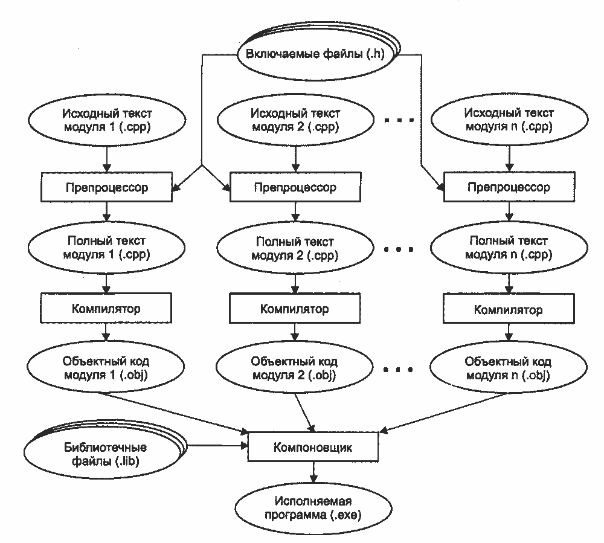

Рис. 1.2. Этапы создания исполняемой программы

Начнём изучение C++ с самого простого — с алфавита, а затем, осваивая всё более сложные элементы, постепенно углубимся в дебри объектно-ориентированного программирования и постараемся в них не заблудиться. К концу изучения этой книги читателю будет легко и приятно порассуждать об «инкапсулированных абстракциях с чётким протоколом доступа», о том, отчего нельзя «сгенерировать исключение, если конструктор копии объекта не является общедоступным», и о многих столь же интересных вещах.

Страница 017

# Алфавит языка

Алфавит C++ включает:

- прописные и строчные латинские буквы и знак подчеркивания;
- арабские цифры от 0 до 9;
- специальные знаки:

```
" { } , | [ ] ( ) + - / % * . \
' : ? < = > ! & # ~ ; ^
```

- пробельные символы: пробел, символы табуляции, символы перехода на новую строку.

Из символов алфавита формируются лексемы языка:

- идентификаторы;
- ключевые (зарезервированные) слова;
- знаки операций;
- константы;
- разделители (скобки, точка, запятая, пробельные символы).

Границы лексем определяются другими лексемами, такими, как разделители или знаки операций.

# Идентификаторы

**Идентификатор** - это имя программного объекта. В идентификаторе могут ис- пользоваться латинские буквы, цифры и знак подчеркивания. Прописные и строчные буквы различаются, например, sysop, SySOP и SYSOP - три различных имени. Первым символом идентификатора может быть буква или знак подчеркивания, но не цифра. Пробелы внутри имен не допускаются.

**СОВЕТ** - Для улучшения читаемости программы следует давать объектам осмысленные имена. Существует соглашение о правилах создания имен, называемое венгерской нотацией (поскольку предложил ее сотрудник компании Microsoft венгр по национальности), по которому каждое слово, составляющее идентификатор, начинается с прописной буквы, а вначале ставится префикс, соответствующий типу величины, например, iMaxLength, lpfnSetFirstDialog. Другая традиция - разделять слова, составляющие имя, знаками подчеркивания: max_length, number_of_galosh.

Длина идентификатора по стандарту не ограничена, но некоторые компиляторы и компоновщики налагают на нее ограничения. Идентификатор создается на этапе объявления переменной, функции, типа и т. п., после этого его можно использовать в последующих операторах программы. При выборе идентификатора необходимо иметь в виду следующее:

- идентификатор не должен совпадать с ключевыми словами (см. следующий раздел) и именами используемых стандартных объектов языка;
- не рекомендуется начинать идентификаторы с символа подчеркивания, поскольку они могут совпасть с именами системных функций или переменных, и, кроме того, это снижает мобильность программы;
- на идентификаторы, используемые для определения внешних переменных галагаются ограничения компоновщика (использование различных компо новщиков или версий компоновщика накладывает разные требования на имена внешних переменных).

Страница 018

# Ключевые слова

**Ключевые слова** - это зарезервированные идентификаторы, которые имеют специальное значение для компилятора. Их можно использовать только в том смысле, в котором они определены. Список ключевых слов С+ + приведен в табл. 1.1.

Таблица 1.1. Список ключевых слов C++

| --- | --- | --- | --- |
| --- | --- | --- | --- |
| asm | else | new | this |
| auto | enum | operator | throw |
| bool | explicit | private | true |
| break | export | protected | try |
| case | extern | public | typedef |
| catch | false | register | typeid |
| char | float | reinterpret_cast | typename |
| class | for | return | union |
| const | friend | short | unsigned |
| const_cast | goto | signed | using |
| continue | if | sizeof | virtual |
| default | inline | static | void |
| delete | int | static_cast | volatile |
| do | long | struct | wchar_t |
| double | mutable | switch | while |
| dynamic_cast | namespace | template | --- |

Страница 019

# Знаки операций

Знак операции — это один или более символов, определяющих действие над операндами. Внутри знака операции пробелы не допускаются. Операции делятся на унарные, бинарные и тернарную по количеству участвующих в них операндов. Один и тот же знак может интерпретироваться по-разному в зависимости от контекста. Все знаки операций за исключением `[ ]`, `( )` и `? :` представляют собой отдельные лексемы. Знаки операций C++ описаны в разделе «Операции», с. 31, а также приведены в приложении 1. Большинство стандартных операций может быть переопределено (перегружено). Перегрузка операций рассмотрена на с. 189.

# Константы

Константами называют неизменяемые величины. Различаются целые, вещественные, символьные и строковые константы. Компилятор, выделив константу в качестве лексемы, относит её к одному из типов по её внешнему виду. Программист может задать тип константы самостоятельно (см. стр. 24).

Форматы констант, соответствующие каждому типу, приведены в табл. 1.2.

Таблица 1.2. Константы в языке C++

Допустимые диапазоны значений целых и вещественных констант приведены в табл. 1.4. Если требуется сформировать отрицательную целую или вещественную конанту, то перед константой ставится знак унарной операции изменения знака `(-)`, например: `-218`, `-022`, `-0х3С`, `-4.8`, `-0.1е4`. Вещественная константа в экспоненциальном формате представляется в виде мантиссы и порядка. Мантисса записывается слева от знака экспоненты (Е или е), порядок - справа от знака. Значение константы определяется как произведение мантиссы и возведенного в указанную в порядке степень числа 10. Обратите внимание, что пробелы внутри числа не допускаются, а для отделения целой части от дробной используется не запятая, а точка.

Символьные константы, состоящие из одного символа, занимают в памяти один байт и имеют стандартный тип char. Двухсимвольные константы занимают два байта и имеют тип int, при этом первый символ размещается в байте с меньшим адресом (о типах данных рассказывается в следующем разделе). Символ обратной косой черты используется для представления:

- кодов, не имеющих графического изображения (например, `\а` - звуковой сигнал, `\п` - перевод курсора в начало следующей строки);
- символов апострофа `(')`, обратной косой черты `(\)`, знака вопроса `(?)` и кавычки `(")`;
- любого символа с помощью его шестнадцатеричного или восьмеричного кода, например, `\073`, `\0xF5`. Числовое значение должно находиться в диапазоне от `0` до `255`.

Последовательности символов, начинающиеся с обратной косой черты, называют управляющими, или escape-последовательностями. В таблице 1.3 приведены их допустимые значения. Управляющая последовательность интерпретируется как одиночный символ. Если непосредственно за обратной косой чертой следует символ, не предусмотренный табл. 1.3, результат интерпретации не определен. Если в последовательности цифр встречается недопустимая, она считается концом цифрового кода.

Страница 020

Таблица 1.3. Управляющие последовательности в языке C++

| Изображение | Шестнадцатеричной код | Наименование |
| --- | --- | --- |
| \a | 7 | Звуковой сигнал |
| \b | 8 | Возврат на шаг |
| \f | C | Перевод страницы (формата) |
| \n | A | Перевод Строка |
| \r | D | Возврат каретки |
| \t | 9 | Горизонтальные табуляция |
| \v | B | Вертикальная табуляция |
| `\\` | 5C | Обратная косая черта |
| `\'` | 27 | Апостроф |
| `\"` | 22 | Кавычка |
| `\?` | 3F | Вопросительный знак |
| `\0ddd` | - | Вы восьмеричный Коды символом |
| `\0xddd` | `ddd` | Шестнадцатеричной коды символа |

Страница 021

Управляющие последовательности могут использоваться и в строковых константах, называемых иначе строковыми литералами. Например, если внутри строки ребуется записать кавычку, ее предваряют косой чертой, по которой компилятор отличает ее от кавычки, ограничивающей строку: `"Издательский дом \"Питер\"`. Все строковые литералы рассматриваются компилятором как различные объекты. **Строковые константы**, отделённые в программе только пробельными символами, при компиляции объединяются в одну. Длинную строковую константу можно разместить на нескольких строках, используя в качестве знака переноса обратную косую черту, за которой следует перевод строки. Эти символы игнорируются компилятором, при этом следующая строка воспринимается как продолжение предыдущей. Например, строка:

```
"Никто не доволен своей \
внешностью, но все довольны \
своим умом"
```

полностью эквивалентна строке:

```
"Никто не доволен своей внешностью, но все довольны своим умом"
```

В конец каждого строкового литерала компилятором добавляется нулевой символ, представляемый управляющей последовательностью `\0`. Поэтому длина строки всегда на единицу больше количества символов в её записи. Таким образом, пустая строка `""` имеет длину 1 байт. Обратите внимание на разницу между строкой из одного символа, например, `"А"`, и символьной константой `'А'`. Пустая символьная константа недопустима.

Страница 022

# Комментарии

Комментарий либо начинается с двух символов «прямая косая черта» (`//`) и заканчивается символом перехода на новую строку, либо заключается между символами-скобками `/*` и `*/`. Внутри комментария можно использовать любые допустимые на данном компьютере символы, а не только символы из алфавита языка C++, поскольку компилятор комментарии игнорирует. Вложенные комментарии-скобки стандартом не допускаются, хотя в некоторых компиляторах разрешены. **СОВЕТ**. Рекомендуется использовать для пояснений `//`-комментарии, а скобки `/* */` применять для временного исключения блоков кода при отладке. Советы по содержанию комментариев см. в разделе «Кодирование и документирование программы», с. 102.

# Типы данных C++

### Концепция типа данных

Основная цель любой программы состоит в обработке данных. Данные различного типа хранятся и обрабатываются по-разному. В любом алгоритмическом языке каждая константа, переменная, результат вычисления выражения или функции должны иметь определённый тип.

Тип данных определяет:

- внутреннее представление данных в памяти компьютера;
- множество значений, которые могут припимать величины этого типа;
- операции и функции, которые можно применять к величинам этого типа.

Исходя из этих характеристик, программист выбирает тип каждой величины, используемой в программе для представления реальных объектов. Обязательное описание типа позволяет компилятору производить проверку допустимости различных конструкций программы. От типа величины зависят машинные команды, которые будут использоваться для обработки данных. Все типы языка C++ можно разделить на основные и составные. В языке C++ определено шесть основных типов данных для представления целых, вещественных, символьных и логических величин. На основе этих типов программист может вводить описание составных типов. К ним относятся массивы, перечисления, функции, структуры, ссылки, указатели, объединения и классы.

# Основные типы данных

Основные (стандартные) типы данных часто называют арифметическими, поскольку их можно использовать в арифметических операциях. Для описания основных типов определены следующие ключевые слова:

- int (целый);
- char (символьный);
- wchar_t (расширешный символьный);
- bool (логический);
- float (вещественный);
- double (вещественный с двойной точностью).

Первые четыре типа называют целочисленными (целыми), последние два — типами с плавающей точкой. Код, который формирует компилятор для обработки целых величин, отличается от кода для величин с плавающей точкой. Существует четыре спецификатора типа, уточняющих внутреннее представлеие и диапазон значений стандартных типов:

- short (короткий);
- long (длинный);
- signed (знаковый);
- unsigned (беззнаковый).

Страница 023

# Целый тип (int)

Размер типа `int` не определяется стандартом, а зависит от компьютера и компилятора. Для 16-разрядного процессора под величины этого типа отводится 2 байта, для 32-разрядного — 4 байта. Спецификатор `short` перед именем типа указывает компилятору, что под число требуется отвести 2 байта независимо от разрядности процессора. Спецификатор `long` означает, что целая величина будет занимать 4 байта. Таким образом, на 16-разрядном компьютере эквиваленты `int` и `short int`, а на 32-разрядном — `int` и `long int`. Внутреннее представление величины целого типа — целое число в двоичном коде. При использовании спецификатора `signed` старший бит числа интерпретируется как знаковый (0 — положительное число, 1 — отрицательное). Спецификатор `unsigned` позволяет представлять только положительные числа, поскольку старший разряд рассматривается как часть кода числа. Таким образом, диапазон значений типа `int` зависит от спецификаторов. Диапазоны значений величин целого типа с различными спецификаторами для IBM PC-совместимых компьютеров приведены в табл. 1.4. По умолчанию все целочисленные типы считаются знаковыми, то есть спецификатор `signed` можно опускать. Константам, встречающимся в программе, приписывается тот или иной тип в соответствии с их видом. Если этот тип по каким-либо причинам не устраивает программиста, он может явно указать требуемый тип с помощью суффиксов `L`, `l` (`long`) и `U`, `u` (`unsigned`). Например, константа `32L` будет иметь тип `long` и занимать 4 байта. Можно использовать суффиксы `L` и `U` одновременно, например, `0x22UL` или `05Lu`.

**ПРИМЕЧАНИЕ.** Типы `short int`, `long int`, `signed int` и `unsigned int` можно сокращать до `short`, `long`, `signed` и `unsigned` соответственно.

# Символьный тип (char)

Под величину символьного типа отводится количество байт, достаточное для размещения любого символа из набора символов для данного компьютера, что и обусловило название типа. Как правило, это 1 байт. Тип `char`, как и другие целые типы, может быть со знаком или без знака. В величинах со знаком можно хранить значения в диапазоне от -128 до 127. При использовании спецификатора `unsigned` значения могут находиться в пределах от 0 до 255. Этого достаточно для хранения любого символа из 256-символьного набора ASCII. Величины типа `char` применяются также для хранения целых чисел, не превышающих границы указанных диапазонов.

# Расширенный символьный тип (wchar_t)

Тип `wchar_t` предназначен для работы с набором символов, для кодировки которых недостаточно 1 байта, например, Unicode. Размер этого типа зависит от реализации; как правило, он соответствует типу `short`. Строковые константы типа `wchar_t` записываются с префиксом `L`, например, `L"Gates"`.

# Логический тип (bool)

Величины логического типа могут принимать только значения `true` и `false`, являющиеся зарезервированными словами. Внутренняя форма представления значения `false` — 0 (нуль). Любое другое значение интерпретируется как `true`. При преобразовании к целому типу `true` имеет значение 1.

Страница 024

# Типы с плавающей точкой (float, double и long double)

Стандарт С++ определяет три типа данных для хранения вещественных значений: `float`, `double` u `long double`. Типы данных с плавающей точкой хранятся в памяти компьютера иначе, чем целочисленные. Внутреннее представление вещественного числа состоит из двух частей — мантиссы и порядка. В IBM PC-совместимых компьютерах величины типа `float` занимают 4 байта, из которых один двоичный разряд отводится под знак мантиссы, 8 разрядов под порядок и 23 под мантиссу. Мантисса — это число, большее 1.0, но меньшее 2.0. Поскольку старшая цифра мантиссы всегда равна 1, она не хранится. Для величин типа `double`, занимающих 8 байт, под порядок и мантиссу отводится 11 и 52 разряда соответственно. Длина мантиссы определяет точность числа, а длина порядка — его диапазон. Как можно видеть из табл. 1.4, при одинаковом количестве байт, отводимом под величины типа `float` и `long int`, диапазоны их допустимых значений сильно различаются из-за внутренней формы представления. **Спецификатор** `long` перед именем типа `double` указывает, что под величину отводится 10 байт. Константы с плавающей точкой имеют по умолчанию тип `double`. Можно явно указать тип константы с помощью суффиксов `F`, `f` (`float`) и `L`, `l` (`long double`). Например, константа `2E+6L` будет иметь тип `long double`, а константа `1.82f` — тип `float`.

Таблица 1.4. Диапазоны значений простых типов данных для ВМ РС

[output not shown]

Для величин типов в таблице приведены абсолютные величины минимальных и максимальных значений. Для написания переносимых на различные платформы программ нельзя делать предположений о размере типа `int`. Для его получения необходимо пользоваться операцией `sizeof`, результатом которой является размер типа в байтах. Например, для операционной системы MS-DOS `sizeof(int)` даст в результате 2, а для Windows 9X или OS/2 результатом будет 4.

Страница 025

В стандарте ANSI диапазоны значений для основных типов не задаются, определяются только соотношения между их размерами, например:

```
sizeof(float) ≤ sizeof(double) ≤ sizeof(long double)
sizeof(char) ≤ sizeof(short) ≤ sizeof(int) ≤ sizeof(long)
```

**ПРИМЕЧАНИЕ.** Минимальные и максимальные допустимые значения для целых типов зависят от реализации и приведены в заголовочном файле `<limits.h>` (`<climits>`), характеристики вещественных типов — в файле `<float.h>` (`<cfloat>`), а также в шаблоне класса `numeric_limits` (см. раздел «Другие средства стандартной библиотеки», с. 378, и приложение 5).

Различные виды целых и вещественных типов, различающиеся диапазоном и точностью представления данных, введены для того, чтобы дать программисту возможность наиболее эффективно использовать возможности конкретной аппаратуры, поскольку от выбора типа зависит скорость вычислений и объём памяти. Но оптимизированная для компьютеров какого-либо одного типа программа может стать не переносимой на другие платформы, поэтому в общем случае следует избегать зависимостей от конкретных характеристик типов данных.

# Тип void

Кроме перечисленных, к основным типам языка относится тип `void`, но множество значений этого типа пусто. Он используется для определения функций, которые не возвращают значения, для указания пустого списка аргументов функции (о функциях рассказывается на с. 73), как базовый тип для указателей (с. 51) и в операции приведения типов (с. 56).

# Структура программы

Программа на языке C++ состоит из функций, описаний и директив препроцессора (с. 16). Одна из функций должна иметь имя `main`. Выполнение программы начинается с первого оператора этой функции. Простейшее определение функции имеет следующий формат:

```
[тип_результата] имя_функции ([список_аргументов])
{
    тело_функции
}
```

Как правило, функция используется для вычисления какого-либо значения, поэтому перед именем функции указывается его тип. О функциях рассказывается на с. 73, ниже приведены лишь самые необходимые сведения:

- если функция не должна возвращать значение, указывается тип void:
- тело функции является блоком и, следовательно, заключается в фигурные скобки;
- функции не могут быть вложенными;
- каждый оператор заканчивается точкой с запятой (кроме составного оператора).

Страница 026

Пример структуры программы, содержащей функции `main`, `f1` и `f2`:

```
// директивы препроцессора
// описания

int main()
{
    // операторы главной функции
}

int f1()
{
    // операторы функции f1
}

int f2()
{
    // операторы функции f2
}
```

Программа может состоять из нескольких модулей (исходных файлов).

Несколько предварительных замечаний о вводе/выводе. В языке C++ нет встроенных средств ввода/вывода — он осуществляется с помощью функций, типов и объектов, содержащихся в стандартных библиотеках. Используется два способа: функции, унаследованные из языка С, и объекты C++. Основные функции ввода/вывода в стиле С:

```
int scanf(const char* format, ...) // ввод
int printf(const char* format, ...) // вывод
```

Они выполняют форматированный ввод и вывод произвольного количества величин в соответствии со строкой формата `format`. Строка формата содержит символы, которые при выводе копируются в поток (на экран) или запрашиваются из потока (с клавиатуры) при вводе, и спецификации преобразования, начинающиеся со знака `%`, которые при вводе и выводе заменяются конкретными величинами. Список наиболее употребительных спецификаций преобразования приведён в приложении 2.

**Пример программы**, использующей функции ввода/вывода в стиле С:

```
#include <stdio.h>
int main()
{
    int i;
    printf("Введите целое число\n");
    scanf("%d", &i);
    printf("Вы ввели число %d, спасибо!", i);
    return 0;
}
```

Первая строка этой программы — директива препроцессора, по которой в текст программы вставляется заголовочный файл `<stdio.h>`, содержащий описание использованных в программе функций ввода/вывода (в данном случае угловые скобки являются элементом языка). Все директивы препроцессора начинаются со знака `#`. Директивы препроцессора описаны на с. 93. Третья строка — описание переменной целого типа с именем `i`. Переменные рассматриваются на с. 28.

Страница 027

Функция `printf` в четвертой строке выводит приглашение «Введите целое число» и переходит на новую строку в соответствии с управляющей последовательностью `\n`. Функция `scanf` заносит введённое с клавиатуры целое число в переменную `i` (знак `&` означает операцию получения адреса), а следующий оператор выводит на экран указанную в нём строку, заменив спецификацию преобразования на значение этого числа. Ввод/вывод в стиле С рассмотрен в разделе «Функции ввода/вывода» (с. 88). А вот как выглядит та же программа с использованием библиотеки классов C++:

```
#include <iostream.h>
int main()
{
    int i;
    cout << "Введите целое число\n";
    cin >> i;
    cout << "Вы ввели число " << i << ", спасибо!";
    return 0;
}
```

Заголовочный файл `<iostream.h>` содержит описание набора классов для управления вводом/выводом. В нём определены стандартные объекты-потоки `cin` для ввода с клавиатуры и `cout` для вывода на экран, а также операции помещения в поток `<<` и чтения из потока `>>`. Потоки рассмотрены в разделе «Потоковые классы» на с. 265. В дальнейшем изложении будут использоваться оба способа, но в одной программе смешивать их не рекомендуется.

# Переменные и выражения

В любой программе требуется производить вычисления. Для вычисления значений используются выражения, которые состоят из операндов, знаков операций и скобок. Операнды задают данные для вычислений. Операции задают действия, которые необходимо выполнить. Каждый операнд является, в свою очередь, выражением или одним из его частных случаев, например, константой или переменной. Операции выполняются в соответствии с приоритетами. Для изменения порядка выполнения операций используются круглые скобки. Рассмотрим составные части выражений и правила их вычисления.

# Переменные

Переменная — это именованная область памяти, в которой хранятся данные определённого типа. У переменной есть имя и значение. Имя служит для обращения к области памяти, в которой хранится значение. Во время выполнения программы значение переменной можно изменять. Перед использованием любая переменная должна быть описана. **Пример** описания целой переменной с именем `a` и вещественной переменной `x`:

```
int a;
float x;
```

Общий вид оператора описания переменных:

```
[класс_памяти] [const] тип имя [инициализатор];
```

Страница 028

Рассмотрим правила задания составных частей этого оператора.

- Необязательный класс памяти может принимать одно из значений `auto`, `extern`, `static` и `register`. О них рассказывается чуть ниже.
- Модификатор `const` показывает, что значение переменной изменять нельзя. Такую переменную называют именованной константой, или просто константой.
- При описании можно присвоить переменной начальное значение, это называется инициализацией. Инициализатор можно записывать в двух формах — со знаком равенства: `= значение` или в круглых скобках: `(значение)`.

Константа должна быть инициализирована при объявлении. В одном операторе можно описать несколько переменных одного типа, разделяя их запятыми.

**Примеры**:

```
short int a = 1;                // целая переменная а
const char C = 'C';             // символьная константа С
char s, sf = 'f';               // инициализация относится только к sf
char t(54);                     // символьная переменная t
float c = 0.22, x(3), sum;      // вещественные переменные
```

Если тип инициализирующего значения не совпадает с типом переменной, выполняются преобразования типа по определённым правилам (см. с. 38 и приложение 3). Описание переменной, кроме типа и класса памяти, явно или по умолчанию задаёт её область действия. Класс памяти и область действия зависят не только от собственно описания, но и от места его размещения в тексте программы.

**Область действия идентификатора** — это часть программы, в которой его можно использовать для доступа к связанной с ним области памяти. В зависимости от области действия переменная может быть локальной или глобальной. Если переменная определена внутри блока (напомню, что блок ограничен фигурными скобками), она называется локальной, область её действия — от точки описания до конца блока, включая все вложенные блоки. Если переменная определена вне любого блока, она называется глобальной и областью её действия считается файл, в котором она определена, от точки описания до его конца.

**Класс памяти** определяет время жизни и область видимости программного объекта (в частности, переменной). Если класс памяти не указан явным образом, он определяется компилятором исходя из контекста объявления. Время жизни может быть постоянным (в течение выполнения программы) и временным (в течение выполнения блока). Областью видимости идентификатора называется часть текста программы, в которой допустим обычный доступ к связанной с идентификатором областью памяти. Чаще всего область видимости совпадает с областью действия. Исключением является ситуация, когда во вложенном блоке описана переменная с таким же именем. В этом случае внешняя переменная во вложенном блоке невидима, хотя он и входит в её область действия. Тем не менее к этой переменной, если она глобальная, можно обратиться, используя операцию доступа к области видимости `::`.

Страница 029

Для задания класса памяти используются следующие спецификаторы:

- `auto` — автоматическая переменная. Память под неё выделяется в стеке и при необходимости инициализируется каждый раз при выполнении оператора, содержащего её определение. Освобождение памяти происходит при выходе из блока, в котором описана переменная. Время её жизни — с момента описания до конца блока. Для глобальных переменных этот спецификатор не используется, а для локальных он принимается по умолчанию, поэтому задавать его явным образом большого смысла не имеет.
- `extern` — означает, что переменная определяется в другом месте программы (в другом файле или дальше по тексту). Используется для создания переменных, доступных во всех модулях программы, в которых они объявлены. Подробнее об употреблении внешних переменных рассказывается в разделе «Внешние объявления», с. 98.
- `static` — статическая переменная. Время жизни — постоянное. Инициализируется один раз при первом выполнении оператора, содержащего определение переменной. В зависимости от расположения оператора описания статические переменные могут быть глобальными и локальными. Глобальные статические переменные видны только в том модуле, в котором они описаны.
- `register` — аналогично `auto`, но память выделяется по возможности в регистрах процессора. Если такой возможности у компилятора нет, переменные обрабатываются как `auto`.

```
int a;                         // 1 глобальная переменная а
int main()
{
    int b;                     // 2 локальная переменная b
    extern int x;              // 3 переменная х определена в другом месте
    static int c;              // 4 локальная статическая переменная с
    a = 1;                     // 5 присваивание глобальной переменной
    int a;                     // 6 локальная переменная а
    a = 2;                     // 7 присваивание локальной переменной
    ::a = 3;                   // 8 присваивание глобальной переменной
    return 0;
}
int x = 4;                     // 9 определение и инициализация х
```

В этом примере глобальная переменная `a` определена вне всех блоков. Память под неё выделяется в сегменте данных в начале работы программы, областью действия является вся программа. Область видимости — вся программа, кроме строк 6–8, так как в первой из них определяется локальная переменная с тем же именем, область действия которой начинается с точки её описания и заканчивается в блоке. Переменная `b` является автоматической, память для неё выделяется в стеке при входе в блок и освобождается при выходе из него, а переменная `c` располагается в сегменте данных и существует всё время, пока работает программа. **Если переменная** в том же операторе инициализируется, спецификатор `extern` игнорируется.

Страница 030

Если при определении начальное значение переменных явным образом не задаётся, компилятор присваивает глобальным и статическим переменным нулевое значение соответствующего типа. Автоматические переменные не инициализируются. Имя переменной должно быть уникальным в своей области действия (например, в одном блоке не может быть двух переменных с одинаковыми именами). Более подробно области действия рассматриваются на с. 97.

**СОВЕТ**. Не жалейте времени на придумывание подходящих имён. Имя должно отражать смысл хранимой величины, быть легко распознаваемым и, желательно, не содержать символов, которые можно перепутать друг с другом, например, `1`, `l` (строчная L) или `I` (прописная i). Для разделения частей имени можно использовать знак подчёркивания. Не давайте переменным имена, демонстрирующие знание иностранного слэнга — ведь «как вы лодку назовёте, так она и поплывёт». Как правило, переменным с большой областью видимости даются более длинные имена (желательно с префиксом типа), а для переменных, вся жизнь которых проходит на протяжении нескольких строк исходного текста, хватит и одной буквы с комментарием при объявлении.

Описание переменной может выполняться в форме объявления или определения. Объявление информирует компилятора о типе переменной и классе памяти, а определение содержит, кроме этого, указание компилятору выделить память в соответствии с типом переменной. В C++ большинство объявлений являются одновременно и определениями. В приведённом выше примере только описание 3 является объявлением, но не определением. Переменная может быть объявлена многократно, но определена только в одном месте программы, поскольку объявление просто описывает свойства переменной, а определение связывает её с конкретной областью памяти.

Страница 031

# Операции

В таблице 1.5 приведён список основных операций, определённых в языке C++, в соответствии с их приоритетами (по убыванию приоритетов, операции с разными приоритетами разделены чертой). Остальные операции будут вводиться по мере изложения. Полный список операций приведён в приложении 1. В соответствии с количеством операндов, которые используются в операциях, они делятся на унарные (один операнд), бинарные (два операнда) и тернарную (три операнда). Все приведённые в таблице операции, кроме условной и `sizeof`, могут быть перегружены. О перегрузке операций рассказывается на с. 189.

Таблица 1.5. Основные операции языка С++

### Унарные операции

| Операция | Краткое описание |
| --- | --- |
| ++ | увеличение на 1 |
| -- | уменьшение на 1 |
| sizeof | размер |
| `~` | поразряднос отрицание |
| `!` | логическое отрицание |
| `-` | арифметическое отрицание (унарный минус) |
| `+` | унарный плюс |
| `&` | взятие адреса |
| `*` | разадресация |
| new | выделение памяти |
| delete | освобождение памяти |
| (type) | преобразование типа |

# Бинарные и тернарная операции

| Операция | Краткое описание |
| --- | --- |
| `*` | умножение |
| `/` | деление |
| `%` | остаток от деления |
| `+` | сложение |
| `-` | вычитание |
| `<<` | сдвиг влево |
| `>>` | сдвиг вправо |
| `<` | меньше |
| `<=` | меньше или равно |
| `>` | больше |
| `>=` | больше или равно |
| `==` | равно |
| `!=` | не равно |

[output not shown]

Пробелы между символами внутри операции не допускаются.

Страница 032

[output not shown]

# Рассмотрим основные операции подробнее.

**Операции увеличения** и уменьшения на 1 (`++` и `--`). Эти операции, называемые также инкрементом и декрементом, имеют две формы записи — префиксную, когда операция записывается перед операндом, и постфиксную. В префиксной форме сначала изменяется операнд, а затем его значение становится результирующим значением выражения, а в постфиксной форме значением выражения является исходное значение операнда, после чего он изменяется.

```
#include <stdio.h>
int main()
{
    int x = 3, y = 3;
    printf("Значение префиксного выражения: %d\n", ++x);
    printf("Значение постфиксного выражения: %d\n", y++);
    printf("Значение х после приращения: %d\n", x);
    printf("Значение у после приращения: %d\n", y);
    return 0;
}
```

Результат работы программы:

- Значение префиксного выражения: 4
- Значение постфиксного выражения: 3
- Значение х после приращения: 4
- Значение у после приращения: 4

Страница 033

Операндом операции инкремента в общем случае является так называемое L-значение (L-value). Так обозначается любое выражение, адресующее некоторый участок памяти, в который можно занести значение. Название произошло от операции присваивания, поскольку именно её левая (Left) часть определяет, в какую область памяти будет занесён результат операции. Переменная является частным случаем L-значения. Операция определения размера `sizeof` предназначена для вычисления размера объекта или типа в байтах и имеет две формы:

```
sizeof выражение
sizeof (тип)
```

**Пример**:

```
#include <iostream.h>
int main()
{
    float x = 1;
    cout << "sizeof (float): " << sizeof(float);
    cout << "\nsizeof x: " << sizeof x;
    cout << "\nsizeof (x + 1.0): " << sizeof(x + 1.0);
    return 0;
}
```

Результат работы программы:

```
sizeof (float): 4
sizeof x: 4
sizeof (x + 1.0): 8
```

Последний результат связан с тем, что вещественные константы по умолчанию имеют тип `double`, к которому, как к более длинному, приводится тип переменной `x` и всего выражения. Скобки необходимы для того, чтобы выражение, стоящее в них, вычислялось раньше операции приведения типа, имеющей больший приоритет, чем сложение.

**Операции отрицания (`-`, `!` и `~`)**. Арифметическое отрицание (унарный минус `-`) изменяет знак операнда целого или вещественного типа на противоположный. Логическое отрицание (`!`) даёт в результате значение 0, если операнд есть истина (не нуль), и значение 1, если операнд равен нулю. Операнд должен быть целого или вещественного типа, а также может иметь тип указатель. Поразрядное отрицание (`~`), часто называемое побитовым, инвертирует каждый разряд в двоичном представлении целочисленного операнда.

**Деление (`/`) и остаток от деления (`%`)**. Операция деления применима к операндам арифметического типа. Если оба операнда целочисленные, результат операции округляется до целого числа, в противном случае тип результата определяется правилами преобразования (см. раздел «Выражения», с. 38, и приложение 3). Операция остатка от деления применяется только к целочисленным операндам. Знак результата зависит от реализации.

```
#include <stdio.h>
int main()
{
    int x = 11, y = 4;
    float z = 4;
    printf("Результаты деления: %d %f\n", x / y, x / z);
    printf("Остаток: %d\n", x % y);
    return 0;
}
```

Страница 034

Результат работы программы:

```
Результаты деления: 2 2.750000
Остаток: 3
```

**Операции сдвига (`<<` и `>>`)** применяются к целочисленным операндам. Они сдвигают двоичное представление первого операнда влево или вправо на количество двоичных разрядов, заданное вторым операндом. При сдвиге влево (`<<`) освободившиеся разряды обнуляются. При сдвиге вправо (`>>`) освободившиеся биты заполняются нулями, если первый операнд беззнакового типа, и знаковым разрядом в противном случае. Операции сдвига не учитывают переполнение и потерю значимости.

**Операции отношения (`<`, `<=`, `>`, `>=`, `==`, `!=`)** сравнивают первый операнд со вторым. Операнды могут быть арифметического типа или указателями. Результатом операции является значение `true` или `false` (любое значение, не равное нулю, интерпретируется как `true`). Операции сравнения на равенство и неравенство имеют меньший приоритет, чем остальные операции сравнения.

**ВНИМАНИЕ**. Обратите внимание на разницу между операцией проверки на равенство (`==`) и операцией присваивания (`=`), результатом которой является значение, присвоенное левому операнду.

**Поразрядные операции (`&`, `|`, `^`)** применяются только к целочисленным операндам и работают с их двоичными представлениями. При выполнении операций операнды сопоставляются побитово (первый бит первого операнда с первым битом второго, второй бит первого операнда со вторым битом второго, и т. д.). При поразрядной конъюнкции, или поразрядном И (операция обозначается `&`), бит результата равен 1 только тогда, когда соответствующие биты обоих операндов равны 1. При поразрядной дизъюнкции, или поразрядном ИЛИ (операция обозначается `|`), бит результата равен 1 тогда, когда соответствующий бит хотя бы одного из операндов равен 1.

При поразрядном исключающем ИЛИ (операция обозначается `^`) бит результата равен 1 только тогда, когда соответствующий бит только одного из операндов равен 1.

```
#include <iostream.h>
int main()
{
    cout << "\n 6 & 5 = " << (6 & 5);
    cout << "\n 6 | 5 = " << (6 | 5);
    cout << "\n 6 ^ 5 = " << (6 ^ 5);
    return 0;
}
```

Результат работы программы:

```
6 & 5 = 4
6 | 5 = 7
6 ^ 5 = 3
```

Страница 035

**Логические операции (`&&` и `||`)**. Операнды логических операций И (`&&`) и ИЛИ (`||`) могут иметь арифметический тип или быть указателями, при этом операнды в каждой операции могут быть различных типов. Преобразования типов не производятся, каждый операнд оценивается с точки зрения его эквивалентности нулю (операнд, равный нулю, рассматривается как `false`, не равный нулю — как `true`). Результатом логической операции является `true` или `false`. Результат операции логическое И имеет значение `true` только если оба операнда имеют значение `true`. Результат операции логическое ИЛИ имеет значение `true`, если хотя бы один из операндов имеет значение `true`. Логические операции выполняются слева направо. Если значения первого операнда достаточно, чтобы определить результат операции, второй операнд не вычисляется.

**Операции присваивания (`=`, `+=`, `-=`, `*=` и т.д.)**. Операции присваивания могут использоваться в программе как законченные операторы. Формат операции простого присваивания (`=`): `операнд_1 = операнд_2`. Первый операнд должен быть L-значением, второй — выражением. Сначала вычисляется выражение, стоящее в правой части операции, а потом его результат записывается в область памяти, указанную в левой части (мнемоническое правило: «присваивание — это передача данных "налево"»). То, что ранее хранилось в этой области памяти, естественно, теряется.

```
#include <iostream.h>
int main()
{
    int a = 3, b = 5, c = 7;
    a = b;
    b = a;
    c = c + 1;
    cout << "a=" << a;
    cout << "\nb=" << b;
    cout << "\nc=" << c;
    return 0;
}
```

Результат работы программы:

```
a=5
b=5
c=8
```

**ВНИМАНИЕ**. При присваивании производится преобразование типа выражения к типу L-значения, что может привести к потере информации.

В сложных операциях присваивания (`+=`, `*=`, `/=` и т.п.) при вычислении выражения, стоящего в правой части, используется и L-значение из левой части. Например, при сложении с присваиванием ко второму операнду прибавляется первый, и результат записывается в первый операнд, то есть выражение `a += b` является более компактной записью выражения `a = a + b`. Условная операция (`?:`). Эта операция тернарная, то есть имеет три операнда. Её формат: `операнд_1 ? операнд_2 : операнд_3`.

Страница 036

Первый операнд может иметь арифметический тип или быть указателем. Он оценивается с точки зрения его эквивалентности нулю (операнд, равный нулю, рассматривается как `false`, не равный нулю — как `true`). Если результат вычисления операнда 1 равен `true`, то результатом условной операции будет значение второго операнда, иначе — третьего операнда. Вычисляется всегда либо второй операнд, либо третий. Их тип может различаться. Условная операция является сокращённой формой условного оператора `if` (он рассмотрен на с. 40).

```
#include <stdio.h>
int main()
{
    int a = 11, b = 4, max;
    max = (b > a) ? b : a;
    printf("Наибольшее число: %d", max);
    return 0;
}
```

Результат работы программы:

```
Наибольшее число: 11
```

Другой пример применения условной операции. Требуется, чтобы некоторая целая величина увеличивалась на 1, если её значение не превышает n, а иначе принимала значение 1:

```
i = (i < n) ? i + 1 : 1;
```

Не рассмотренные в этом разделе операции будут описаны позже.

# Выражения

Как уже говорилось выше, выражения состоят из операндов, знаков операций и скобок и используются для вычисления некоторого значения определённого типа. Каждый операнд является, в свою очередь, выражением или одним из его частных случаев — константой или переменной.

Примеры выражений:

```
(a + 0.12) / 6
x & 8
y || z
(t * sin(x) - 1.05e4) / ((2 * k + 2) * (2 * k + 3))
```

Операции выполняются в соответствии с приоритетами. Для изменения порядка выполнения операций используются круглые скобки. Если в одном выражении записано несколько операций одинакового приоритета, унарные операции, условная операция и операции присваивания выполняются справа налево, остальные — слева направо. Например, `a = b = c` означает `a = (b = c)`, а `a + b + c` означает `(a + b) + c`. Порядок вычисления подвыражений внутри выражений не определён: например, нельзя считать, что в выражении `(sin(x + 2) + cos(y + 1))` обращение к синусу будет выполнено раньше, чем к косинусу, и что `x + 2` будет вычислено раньше, чем `y + 1`. Результат вычисления выражения характеризуется значением и типом. Например, если `a` и `b` — переменные целого типа и описаны так:

```
int a = 2, b = 5;
```

то выражение `a + b` имеет значение 7 и тип `int`, а выражение `a = b` имеет значение, равное помещённому в переменную `a` (в данном случае 5), и тип, совпадающий с типом этой переменной. Таким образом, в C++ допустимы выражения вида `a = b = c`: сначала вычисляется выражение `b = c`, а затем его результат становится правым операндом для операции присваивания переменной `a`. В выражение могут входить операнды различных типов. Если операнды имеют одинаковый тип, то результат операции будет иметь тот же тип. Если операнды разного типа, перед вычислениями выполняются преобразования типов по определённым правилам, обеспечивающим преобразование более коротких типов в более длинные для сохранения значимости и точности.

Страница 037

Преобразования бывают двух типов:

1. Изменяющие внутреннее представление величин (с потерей точности или без потери точности);
2. Изменяющие только интерпретацию внутреннего представления.

К первому типу относится, например, преобразование целого числа в вещественное (без потери точности) и наоборот (возможно, с потерей точности), ко второму — преобразование знакового целого в беззнаковое. В любом случае величины типов `char`, `signed char`, `unsigned char`, `short int` и `unsigned short int` преобразуются в тип `int`, если он может представить все значения, или в `unsigned int` в противном случае. После этого операнды преобразуются к типу наиболее длинного из них, и он используется как тип результата. Правила преобразований приведены в приложении 3. Программист может задать преобразования типа явным образом (об этом рассказывается в разделе «Преобразования типов» на с. 231). Итак, мы потратили достаточно много времени, рассматривая самый нижний уровень конструкций, составляющих язык программирования, и теперь пора начинать строить из них нечто более осмысленное — сначала отдельные операторы, а затем программы. Даже самая простая программа должна создаваться по определённым правилам, тогда она будет надёжна, эффективна и красива. Изучением этих правил мы и займёмся в следующем разделе.

# Базовые конструкции структурного программирования

В теории программирования доказано, что программу для решения задачи любой сложности можно составить только из трёх структур, называемых следованием, ветвлением и циклом. Этот результат установлен Боймом и Якопини ещё в 1966 году путём доказательства того, что любую программу можно преобразовать в эквивалентную, состоящую только из этих структур и их комбинаций. Следование, ветвление и цикл называют базовыми конструкциями структурного программирования. Следованием называется конструкция, представляющая собой последовательное выполнение двух или более операторов (простых или составных). Ветвление задаёт выполнение либо одного, либо другого оператора в зависимости от выполнения какого-либо условия. Цикл задаёт многократное выполнение оператора (рис. 1.3). Особенностью базовых конструкций является то, что любая из них имеет только один вход и один выход, поэтому конструкции могут вкладываться друг в друга произвольным образом, например, цикл может содержать следование из двух ветвлений, каждое из которых включает вложенные циклы (рис. 1.4).

Страница 038

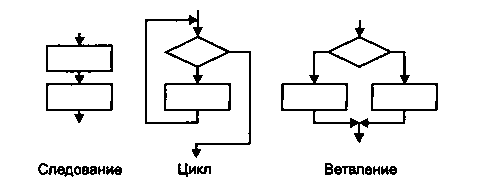

Рис. 1.3. Базовые конструкции структурного программирования

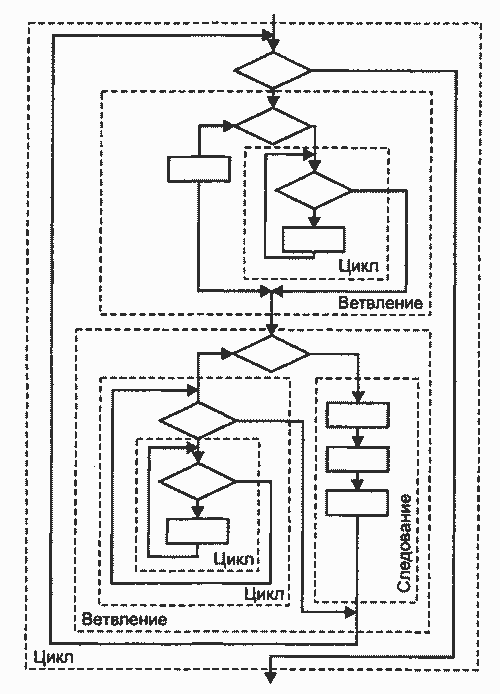

Рис. 1.4. Вложение базовых конструкций

Целью использования базовых конструкций является получение программы простой структуры. Такую программу легко читать (а программы чаще приходится читать, чем писать), отлаживать и при необходимости вносить в нее изменения. Структурное программирование часто называли «программированием без `goto`», и в этом есть большая доля правды: частое использование операторов передачи управления в произвольные точки программы затрудняет прослеживание логики ее работы. С другой стороны, никакие принципы нельзя возводить в абсолют, и есть ситуации, в которых использование `goto` оправдано и приводит, напротив, к упрощению структуры программы. О них говорится в разделе «Оператор `goto`» (c. 49). **В большинстве языков высокого уровня** существует несколько реализаций базовых конструкций; в C++ есть три вида циклов и два вида ветвлений (на два и на произвольное количество направлений). Они введены для удобства программирования, и в каждом случае надо выбирать наиболее подходящие средства. Главное, о чем нужно помнить даже при написании самых простых программ, — что они должны состоять из четкой последовательности блоков строго определенной конфигурации. «Кто ясно мыслит, тот ясно излагает» — практика давно показала, что программы в стиле «поток сознания» нежизнеспособны, не говоря о том, что они просто некрасивы. Рассмотрим операторы языка, реализующие базовые конструкции структурного программирования.

Страница 039

# Оператор «выражение»

Любое выражение, завершающееся точкой с запятой, рассматривается как оператор, выполнение которого заключается в вычислении выражения. Частным случаем выражения является пустой оператор `;` (он используется, когда по синтаксису оператор требуется, а по смыслу — нет). Примеры:

```
i++;
// выполняется операция инкремента
a *= b + c;
// выполняется умножение с присваиванием
fun(i, k);
// выполняется вызов функции
```

# Операторы ветвления

### Условный оператор if

Условный оператор `if` используют для ветвления процесса вычислений на два направления.

**Синтаксис оператора**:

```
if (выражение) оператор_1; [else оператор_2;]
```

Сначала вычисляется выражение, которое может иметь арифметический тип или тип указателя. Если оно не равно нулю (имеет значение `true`), выполняется первый оператор, иначе — второй. После этого управление передается на оператор, следующий за условным.

Одна из ветвей может отсутствовать, логичнее опускать вторую ветвь вместе с ключевым словом `else`. Если в какой-либо ветви требуется выполнить несколько операторов, их необходимо заключить в блок, иначе компилятор не сможет понять, где заканчивается ветвление. Блок может содержать любые операторы, в том числе описания и другие условные операторы (но не может состоять из одних описаний). Необходимо учитывать, что переменная, описанная в блоке, вне блока не существует.

Страница 040

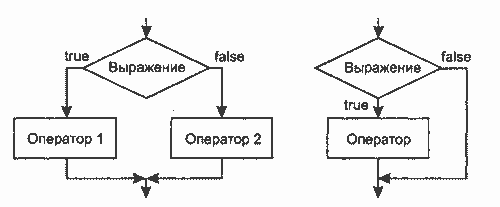

Рис. 1.5. Структурная схема условного оператора

Примеры:

```
if (a < 0) b = 1;
if (a < b && (a > d || a == 0)) b++; else {b *= a; a = 0;}
if (a < b) {if (a < c) m = a; else m = c;} else {if (b < c) m = b; else m = c;} // 3
if (a++) b++;
if (b > a) max = b; else max = a; // 1
```

**Если требуется** проверить несколько условий, их объединяют знаками логических операций. Например, выражение в примере 2 будет истинно в том случае, если выполнится одновременно условие `a < b` и одно из условий в скобках. Если опустить внутренние скобки, будет выполнено сначала логическое `И`, а потом — `ИЛИ`.

**Оператор в примере 3** вычисляет наименьшее значение из трех переменных. Фигурные скобки в данном случае не обязательны, так как компилятор относит часть `else` к ближайшему `if`.

**Пример 4** напоминает о том, что хотя в качестве выражений в операторе `if` чаще всего используются операции отношения, это не обязательно.

**Пример**. Производится выстрел по мишени, изображенной на рис. 1.6. Определить количество очков.

```
#include <iostream.h>
int main()
{
    float x, y; int kol;
    cout << "Введите координаты выстрела \n";
    cin >> x >> y;
    if (x*x + y*y < 1) kol = 2;
    else if (x*x + y*y < 4) kol = 1;
    else kol = 0:
    cout « "In ОчКов: " « kol;
    return 0:
}
```

Страница 041

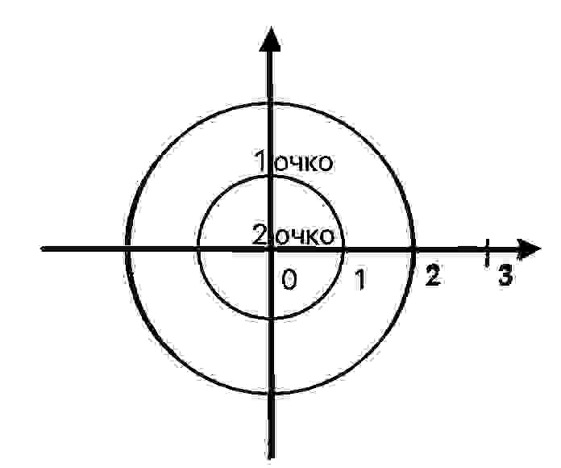

Рис. 1.6. Мишень

**ВНИМАНИЕ** Распространенная ошибка при записи условных операторов — использование в выражениях вместо проверки на равенство (`==`) простого присваивания (`=`), например, `if (a = 1) b = 0;`. Синтаксической ошибки нет, так как операция присваивания формирует результат, который и оценивается на равенство/неравенство нулю. В данном примере присваивание переменной `b` будет выполнено независимо от значения переменной `a`. Поэтому в выражениях проверки переменной на равенство константе константу рекомендуется записывать слева от операции сравнения: `if (1 == a) b = 0;`.

**Вторая ошибка** — неверная запись проверки на принадлежность диапазону. Например, чтобы проверить условие `0 < x && x < 1`, нельзя записать его в условном операторе непосредственно как `if (0 < x < 1)`, так как будет выполнено сначала сравнение `0 < x`, а его результат (`true` или `false`, преобразованное в `int`) будет сравниваться с `1`. Правильный способ записи: `if (0 < x && x < 1)`.

Тип переменных выбирается исходя из их назначения. Координаты выстрела нельзя представить целыми величинами, так как это приведет к потере точности результата, а счетчик очков не имеет смысла описывать как вещественный. Даже такую простую программу можно еще упростить с помощью промежуточной переменной и записи условия в виде двух последовательных, а не вложенных, операторов `if` (обратите внимание, что в первом варианте значение переменной `kol` присваивается ровно один раз, а во втором — от одного до трех раз в зависимости от выполнения условий):

```
#include <iostream.h>
int main()
{
    float x, y, temp; int kol;
    cout << "Введите координаты выстрела\n";
    cin >> x >> y;
    temp = x * x + y * y;
    kol = 0;
    if (temp < 4) kol = 1;
    if (temp < 1) kol = 2;
    cout << "\n Очков: " << kol;
    return 0;
}
```

Если какая-либо переменная используется только внутри условного оператора, рекомендуется объявить ее внутри скобок, например:

```
if (int i = fun(t)) a -= i; else a += i;
```

[output not shown]

Объявление переменной в тот момент, когда она требуется, то есть когда ей необходимо присвоить значение, является признаком хорошего стиля и позволяет избежать случайного использования переменной до ее инициализации. Внутри оператора `if` можно объявить только одну переменную. Область ее видимости начинается в точке объявления и включает обе ветви оператора.

Страница 042

# Оператор switch

Оператор `switch` (переключатель) предназначен для разветвления процесса вычислений на несколько направлений. Формат оператора:

```
switch (выражение)
{
    case константное_выражение_1: [список_операторов_1]
    case константное_выражение_2: [список_операторов_2]
    case константное_выражение_n: [список_операторов_n]
    [default: операторы]
}
```

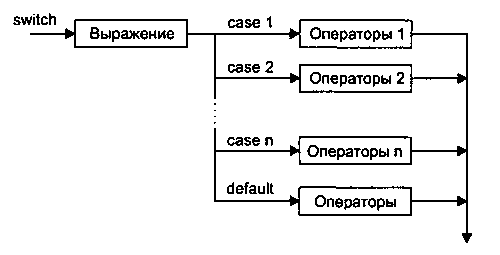

Рис. 1.7. Структурная схема оператора switch

Выполнение оператора начинается с вычисления выражения (оно должно быть целочисленным), а затем управление передается первому оператору из списка, помеченного константным выражением, значение которого совпало с вычисленным. После этого, если выход из переключателя явно не указан, последовательно выполняются все остальные ветви. **Выход из переключателя** обычно выполняется с помощью операторов `break` или `return`. Оператор `break` выполняет выход из самого внутреннего из объемлющих его операторов `switch`, `for`, `while` и `do`. Оператор `return` выполняет выход из функции, в теле которой он записан.

Страница 043

Все константные выражения должны быть одного и того же целочисленного типа. Если совпадения не произошло, выполняются операторы, расположенные после слова `default` (а при его отсутствии управление передается следующему за `switch` оператору). Пример (программа реализует простейший калькулятор на 4 действия):

```
#include <iostream.h>
int main()
{
    int a, b, res;
    char op;
    cout << "\nВведите 1й операнд : "; cin >> a;
    cout << "\nВведите знак операции : "; cin >> op;
    cout << "\nВведите 2й операнд : "; cin >> b;
    bool f = true;
    switch (op)
    {
        case '+': res = a + b; break;
        case '-': res = a - b; break;
        case '*': res = a * b; break;
        case '/': res = a / b; break;
        default: cout << "\nНеизвестная операция"; f = false;
    }
    if (f) cout << "\nРезультат : " << res;
    return 0;
}
```

**ПРИМЕЧАНИЕ** В случае синтаксической ошибки в слове `default` сообщение об ошибке не выдается, поскольку компилятор воспримет это слово как допустимую метку оператора.

Страница 044

# Операторы цикла

Операторы цикла используются для организации многократно повторяющихся вычислений. Любой цикл состоит из тела цикла, то есть тех операторов, которые выполняются несколько раз, начальных установок, модификации параметра цикла и проверки условия продолжения выполнения цикла. Один проход цикла называется итерацией. Проверка условия выполняется на каждой итерации либо до тела цикла (тогда говорят о цикле с предусловием), либо после тела цикла (цикл с постусловием). Разница между ними состоит в том, что тело цикла с постусловием всегда выполняется хотя бы один раз, после чего проверяется, надо ли его выполнять еще раз. Проверка необходимости выполнения цикла с предусловием делается до тела цикла, поэтому возможно, что он не выполнится ни разу.

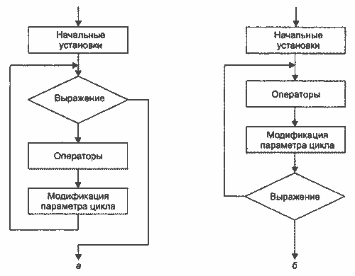

Рис. 1.8. Структурные схемы операторов цикла: а — цикл с предусловием; б — цикл с постусловием

Переменные, изменяющиеся в теле цикла и используемые при проверке условия продолжения, называются параметрами цикла. Целочисленные параметры цикла, изменяющиеся с постоянным шагом на каждой итерации, называются счетчиками цикла. Начальные установки могут явно не присутствовать в программе, их смысл состоит в том, чтобы до входа в цикл задать значения переменным, которые в нем используются. Цикл завершается, если условие его продолжения не выполняется. Возможно принудительное завершение как текущей итерации, так и цикла в целом. Для этого служат операторы `break`, `continue`, `return` и `goto` (см. раздел «Операторы передачи управления», с. 49). Передавать управление извне внутрь цикла не рекомендуется. Для удобства, а не по необходимости, в C++ есть три разных оператора цикла — `while`, `do while` и `for`.

# Цикл с предусловием (while)

Цикл с предусловием реализует структурную схему, приведенную на рис. 1.8, а, и имеет вид:

```
while (выражение) оператор
```

Выражение определяет условие повторения тела цикла, представленного простым или составным оператором. Выполнение оператора начинается с вычисления выражения. Если оно истинно (не равно `false`), выполняется оператор цикла. Если при первой проверке выражение равно `false`, цикл не выполнится ни разу. Выражение может быть логическим или приводимым к нему.

Страница 045

Пример (программа печатает таблицу значений функции `y = x² + 1` во введенном диапазоне):

```
#include <stdio.h>
int main()
{
    float Xn, Xk, Dx;
    printf("Введите диапазон и шаг изменения аргумента: ");
    scanf("%f%f%f", &Xn, &Xk, &Dx);
    printf("|   X   |   y   |\n"); // шапка таблицы
    float x = Xn; // установка параметра цикла
    while (x <= Xk) // проверка условия продолжения
    {
        printf("| %5.2f | %5.2f |\n", x, x * x + 1); // тело цикла
        x += Dx; // модификация параметра
    }
    return 0;
}
```

Пример (программа находит все делители целого положительного числа):

```
#include <iostream.h>
int main()
{
    int num;
    cout << "\nВведите число : "; cin >> num;
    int half = num / 2; // половина числа
    int div = 2; // кандидат на делитель
    while (div <= half)
    {
        if (!(num % div)) cout << div << "\n";
        div++;
    }
    return 0;
}
```

Распространенный прием программирования — организация бесконечного цикла с заголовком `while (true)` либо `while (1)` и принудительным выходом из тела цикла по выполнению какого-либо условия.

В круглых скобках после ключевого слова `while` можно вводить описание переменной. Областью ее действия является цикл:

```
while (int x = 0) { ... /* область действия x */ }
```

В старых версиях компиляторов это требование стандарта может не подлерживаться.

Страница 046

# Цикл с постусловием (do while)

Цикл с постусловием реализует структурную схему, приведенную на рис. 1.8, б, и имеет вид:

```
do оператор while (выражение);
```

Сначала выполняется простой или составной оператор, составляющий тело цикла, а затем вычисляется выражение. Если оно истинно (не равно `false`), тело цикла выполняется еще раз. Цикл завершается, когда выражение станет равным `false` или в теле цикла будет выполнен какой-либо оператор передачи управления. Тип выражения должен быть арифметическим или приводимым к нему.

```
#include <iostream.h>
int main()
{
    char answer;
    do
    {
        cout << "\nКупи ЗЕЛЕНОГО слоника! "; cin >> answer;
    } while (answer != 'y');
    return 0;
}
```

```
#include <stdio.h>
#include <math.h>
int main()
{
    double X, Eps; // аргумент и точность
    double Yp, Y = 1; // предыдущее и последующее приближение
    printf("Введите аргумент и точность:");
    scanf("%lf%lf", &X, &Eps);

    do
    {
        Yp = Y;
        Y = (Yp + X / Yp) / 2;
    } while (fabs(Y - Yp) >= Eps);

    printf("\nКорень из %lf равен %lf", X, Y);
    return 0;
}
```

Страница 047

# Цикл с параметром (for)

Цикл с параметром имеет следующий формат:

```
for (инициализация; выражение; модификации) оператор;
```

Инициализация используется для объявления и присвоения начальных значений величинам, используемым в цикле. В этой части можно записать несколько операторов, разделенных запятой (операцией «последовательное выполнение»), например, так:

```
for (int i = 0, j = 2; ...
int k, m;
for (k = 1, m = 0; ...
```

Областью действия переменных, объявленных в части инициализации цикла, является цикл. Инициализация выполняется один раз в начале исполнения цикла. Выражение определяет условие выполнения цикла: если его результат, приведенный к типу `bool`, равен `true`, цикл выполняется. Цикл с параметром реализован как цикл с предусловием. Модификации выполняются после каждой итерации цикла и служат обычно для изменения параметра цикла. В части модификаций можно записать несколько операторов через запятую. Простой или составной оператор представляет собой тело цикла. Любая из частей оператора `for` может быть опущена (но точки с запятой надо оставить на своих местах!). Пример (оператор, вычисляющий сумму чисел от 1 до 100):

```
for (int i = 1, s = 0; i <= 100; i++) s += i;
```

**Пример** (программа печатает таблицу значений функции у=х2+1 во введенном диапазоне):

```
#include <stdio.h>
int main()
{
    float Xn, Xk, Dx, x;
    printf("Введите диапазон и шаг изменения аргумента: ");
    scanf("%f%f%f", &Xn, &Xk, &Dx);
    printf("|   X   |   Y   |\n");
    for (x = Xn; x <= Xk; x += Dx)
        printf("| %5.2f | %5.2f |\n", x, x * x + 1);
    return 0;
}
```

**Пример** (программа находит все делители целого положительного числа):

```
#include <iostream.h>
int main()
{
    int num, half, div;
    cout << "\nВведите число : ";
    cin >> num;
    for (half = num / 2, div = 2; div <= half; div++)
        if (!(num % div)) cout << div << "\n";
    return 0;
}
```

Два последних примера выполняют те же действия, что и примеры для цикла с предусловием, но записаны более компактно и наглядно: все действия, связанные с управлением циклом, локализованы в его заголовке.

Любой цикл `while` может быть приведен к эквивалентному ему циклу `for` и наоборот по следующей схеме:

```
for (b1; b2; b3) оператор;
```

эквивалентен

```
b1;
while (b2)
{
    оператор;
    b3;
}
```

Часто встречающиеся ошибки при программировании циклов — использование в теле цикла неинициализированных переменных и неверная запись условия выхода из цикла.

Страница 048

Чтобы избежать ошибок, рекомендуется:

- проверить, всем ли переменным, встречающимся в правой части операторов присваивания в теле цикла, присвоены до этого начальные значения (а также возможно ли выполнение других операторов);
- проверить, изменяется ли в цикле хотя бы одна переменная, входящая в условие выхода из цикла;
- предусмотреть аварийный выход из цикла по достижению некоторого количества итераций (см. пример в следующем разделе);
- и, конечно, не забывать о том, что если в теле цикла требуется выполнить более одного оператора, нужно заключать их в фигурные скобки.

**Операторы цикла взаимозаменяемы**, но можно привести некоторые рекомендации по выбору наилучшего в каждом конкретном случае.

**Оператор `do while`** обычно используют, когда цикл требуется обязательно выполнить хотя бы раз (например, если в цикле производится ввод данных).

**Оператором `while`** удобнее пользоваться в случаях, когда число итераций заранее не известно, очевидных параметров цикла нет или модификацию параметров удобнее записывать не в конце тела цикла.

**Оператор `for`** предпочтительнее в большинстве остальных случаев (однозначно — для организации циклов со счетчиками).

# Операторы передачи управления**

В C++ есть четыре оператора, изменяющих естественный порядок выполнения вычислений:

- оператор безусловного перехода `goto`;
- оператор выхода из цикла `break`;
- оператор перехода к следующей итерации цикла `continue`;
- оператор возврата из функции `return`.

# Оператор goto

Оператор безусловного перехода `goto` имеет формат:

```
goto метка;
```

В теле той же функции должна присутствовать ровно одна конструкция вида:

```
метка: оператор;
```

Оператор `goto` передает управление на помеченный оператор. Метка — это обычный идентификатор, областью видимости которого является функция, в теле которой он задан.

Страница 049

Использование оператора безусловного перехода оправдано в двух случаях:

- принудительный выход вниз по тексту программы из нескольких вложенных циклов или переключателей;
- переход из нескольких мест функции в одно (например, если перед выходом из функции всегда необходимо выполнять какие-либо действия).

В остальных случаях для записи любого алгоритма существуют более подходящие средства, а использование `goto` приводит только к усложнению структуры программы и затруднению отладки. Применение `goto` нарушает принципы структурного и модульного программирования, по которым все блоки, из которых состоит программа, должны иметь только один вход и один выход. В любом случае не следует передавать управление внутрь операторов `if`, `switch` и циклов. Нельзя переходить внутрь блоков, содержащих инициализацию переменных, на операторы, расположенные после нее, поскольку в этом случае инициализация не выполнена.

```
int k; //...
goto metka; //...
{
    int a = 3, b = 4;
    k = a + b;
metka:
    int m = k + 1; ...
}
```

После выполнения этого фрагмента программы значение переменной `m` не определено.

# Оператор break

Оператор `break` используется внутри операторов цикла или `switch` для обеспечения перехода в точку программы, находящуюся непосредственно за оператором, внутри которого находится `break`.

Страница 050

```
#include <iostream.h>
#include <math.h>
int main()
{
    const int MaxIter = 500; // ограничитель количества итераций
    double x, eps;
    cout << "\nВведите аргумент и точность: ";
    cin >> x >> eps;
    bool flag = true; // признак успешного вычисления
    double y = x, ch = x; // сумма и первый член ряда
    for (int n = 0; fabs(ch) > eps; n++)
    {
        ch *= x * x / (2 * n + 2) / (2 * n + 3); // очередной член ряда
        y += ch;
        if (n > MaxIter)
        {
            cout << "\nРяд расходится!";
            flag = false; break;
        }
    }
    if (flag) cout << "\nЗначение функции: " << y;
    return 0;
}
```

# Оператор continue

Оператор перехода к следующей итерации цикла `continue` пропускает все операторы, оставшиеся до конца тела цикла, и передает управление на начало следующей итерации.

# Оператор return

Оператор возврата из функции `return` завершает выполнение функции и передает управление в точку ее вызова. Вид оператора:

```
return [выражение];
```

Выражение должно иметь скалярный тип. Если тип возвращаемого функцией значения описан как `void`, выражение должно отсутствовать.

# Указатели и массивы

### Указатели

Когда компилятор обрабатывает оператор определения переменной, например, `int i = 10;`, он выделяет память в соответствии с типом (`int`) и инициализирует ее указанным значением (`10`). Все обращения в программе к переменной по ее имени (`i`) заменяются компилятором на адрес области памяти, в которой хранится значение переменной. Программист может определить собственные переменные для хранения адресов областей памяти. Такие переменные называются указателями. **Итак**, указатели предназначены для хранения адресов областей памяти. В C++ различают три вида указателей — указатели на объект, на функцию и на `void`, отличающиеся свойствами и набором допустимых операций. Указатель не является самостоятельным типом, он всегда связан с каким-либо другим конкретным типом.

Страница 051

Указатель на функцию содержит адрес в сегменте кода, по которому располагается исполняемый код функции, то есть адрес, по которому передается управление при вызове функции. Указатели на функции используются для косвенного вызова функции (не через ее имя, а через обращение к переменной, хранящей ее адрес), а также для передачи имени функции в другую функцию в качестве параметра. Указатель функции имеет тип «указатель функции, возвращающей значение заданного типа и имеющей аргументы заданного типа»:

```
тип (*имя)(список_типов_аргументов);
```

Например, объявление:

```
int (*fun)(double, double);
```

дает указатель с именем `fun` на функцию, возвращающую значение типа `int` и имеющую два аргумента типа `double`. **Указатель на объект** содержит адрес области памяти, в которой хранятся данные определенного типа (основного или составного). Простейшее объявление указателя на объект (в дальнейшем называемого просто указателем) имеет вид:

```
тип *имя;
```

где тип может быть любым, кроме ссылки и битового поля, причем тип может быть к этому моменту только объявлен, но еще не определен (следовательно, в структуре, например, может присутствовать указатель на структуру того же типа). **Звездочка относится** непосредственно к имени, поэтому для того, чтобы объявить несколько указателей, требуется ставить ее перед именем каждого из них. Например, в операторе

```
int *a, b, *c;
```

описываются два указателя на целое с именами `a` и `c`, а также целая переменная `b`.

Размер указателя зависит от модели памяти. Можно определить указатель на указатель и т. д. Указатель на `void` применяется в тех случаях, когда конкретный тип объекта, адрес которого требуется хранить, не определен (например, если в одной и той же переменной в разные моменты времени требуется хранить адреса объектов различных типов). **Указателю на `void`** можно присвоить значение указателя любого типа, а также сравнивать его с любыми указателями, но перед выполнением каких-либо действий с областью памяти, на которую он ссылается, требуется преобразовать его к конкретному типу явным образом. **Указатель может** быть константой или переменной, а также указывать на конанту или переменную. Рассмотрим примеры:

```
int i; // целая переменная
const int ci = 1; // целая константа
int *pi; // указатель на целую переменную
const int *pci; // указатель на целую константу
int *const cp = &i; // указатель-константа на целую переменную
const int *const cpc = &ci; // указатель-константа на целую константу
```

Как видно из примеров, модификатор `const`, находящийся между именем указателя и звездочкой, относится к самому указателю и запрещает его изменение, а `const` слева от звездочки задает постоянство значения, на которое он указывает. Для инициализации указателей использована операция получения адреса `&`. Величины типа указатель подчиняются общим правилам определения области действия, видимости и времени жизни.

Страница 052

# Инициализация указателей

Указатели чаще всего используют при работе с динамической памятью, называемой некоторыми эстетами кучей. Это свободная память, в которой можно во время выполнения программы выделять место в соответствии с потребностями. Доступ к выделенным участкам динамической памяти, называемым динамическими переменными, производится только через указатели. Время жизни динамических переменных — от точки создания до конца программы или до явного освобождения памяти. В C++ используется два способа работы с динамической памятью. Первый использует семейство функций `malloc` и достался в наследство от C, второй использует операции `new` и `delete`. **При определении указателя** надо стремиться выполнить его инициализацию, то есть присвоение начального значения. Непреднамеренное использование неинициализированных указателей — распространенный источник ошибок в программах. Инициализатор записывается после имени указателя либо в круглых скобках, либо после знака равенства.

Существуют следующие способы инициализации указателя:

**Во первых** Присваивание указателю адреса существующего объекта:

```
// с помощью операции получения адреса:
int a = 5; // целая переменная
int* p = &a; // в указатель записывается адрес а
int* p(&a); // то же самое другим способом
// с помощью значения другого инициализированного указателя:
int* r = p;
```

С помощью имени массива или функции, которые трактуются как адрес (см. «Массивы», с. 58, и «Передача имен функций в качестве параметров», с. 80):

```
int b[10]; // массив
int* t = b; // присваивание адреса начала массива
//..
void f(int a) {/* ...*/} // определение функции
void (*pf)(int); // указатель на функцию
pf = f; // присваивание адреса функции
```

Страница 053

**Во третьих**. Присваивание пустого значения.

```
int* suxx = NULL;
int* rulez = 0;
```

В первой строке используется константа `NULL`, определенная в некоторых заголовочных файлах C как указатель, равный нулю. Рекомендуется использовать просто `0`, так как это значение типа `int` будет правильно преобразовано стандартными способами в соответствии с контекстом. Поскольку гарантируется, что объектов с нулевым адресом нет, пустой указатель можно использовать для проверки, ссылается указатель на конкретный объект или нет.

**В четвертых**. Выделение участка динамической памяти и присваивание ее адреса указателю:

```
// с помощью операции new:
int* n = new int; // 1
int* m = new int(10); // 2
int* q = new int[10]; // 3
// с помощью функции malloc:
int* u = (int*)malloc(sizeof(int)); // 4
```

**В операторе 1** операция `new` выполняет выделение достаточного для размещения величины типа `int` участка динамической памяти и записывает адрес начала этого участка в переменную `n`. Память под саму переменную `n` (размера, достаточного для размещения указателя) выделяется на этапе компиляции.

**В операторе 2**, кроме описанных выше действий, производится инициализация выделенной динамической памяти значением `10`.

**В операторе 3** операция `new` выполняет выделение памяти под 10 величин типа `int` (массива из 10 элементов) и записывает адрес начала этого участка в переменную `q`, которая может трактоваться как имя массива. Через имя можно обращаться к любому элементу массива. О массивах рассказывается на с. 58. Если память выделить не удалось, операция `new` порождает исключительную ситуацию (об исключениях — на с. 222, а об обработке ошибок выделения памяти — на с. 378). Старые версии компиляторов могут возвращать `0`.

**В операторе 4** делается то же самое, что и в операторе 1, но с помощью функции выделения памяти `malloc`, унаследованной из библиотеки C. В функцию передается один параметр — количество выделяемой памяти в байтах. Конструкция `(int*)` используется для приведения типа указателя, возвращаемого функцией, к требуемому типу (о явном преобразовании типов см. с. 231). Если память выделить не удалось, функция возвращает `0`. Для того чтобы использовать `malloc`, требуется подключить к программе заголовочный файл `<malloc.h>`. Операцию `new` использовать предпочтительнее, чем функцию `malloc`, особенно при работе с объектами. Освобождение памяти, выделенной с помощью операции `new`, должно выполняться с помощью `delete`, а памяти, выделенной функцией `malloc` — посредством функции `free`. При этом переменная-указатель сохраняется и может инициализироваться повторно. Приведенные выше динамические переменные уничтожаются следующим образом:

```
delete n; delete m; delete [] q; free(u);
```

Страница 054

Если память выделялась с помощью `new[]`, для освобождения памяти необходимо применять `delete[]`. Размерность массива при этом не указывается. Если квадратных скобок нет, то никакого сообщения об ошибке не выдается, но помечен как свободный будет только первый элемент массива, а остальные окажутся недоступны для дальнейших операций. Такие ячейки памяти называются мусором.

**ВНИМАНИЕ** Если переменная-указатель выходит из области своего действия, отведенная под нее память освобождается. Следовательно, динамическая переменная, на которую ссылался указатель, становится недоступной. При этом память из-под самой динамической переменной не освобождается. Другой случай появления «мусора» — когда инициализированному указателю присваивается значение другого указателя. При этом старое значение бесследно теряется.

С помощью комбинации звездочек, круглых и квадратных скобок можно описать составные типы и указатели на составные типы, например, в операторе

```
int *(*p[10])();
```

объявляется массив из 10 указателей на функции без параметров, возвращающих указатели на `int`.

По умолчанию квадратные и круглые скобки имеют одинаковый приоритет, больший, чем звездочка, и рассматриваются слева направо. Для изменения порядка рассмотрения используются круглые скобки. При чтении сложных описаний необходимо придерживаться правила «изнутри наружу»:

1. если справа от имени имеются квадратные скобки, это массив, если скобки круглые — это функция;
2. если слева есть звездочка, это указатель на проинтерпретированную ранее конструкцию;
3. если справа встречается закрывающая круглая скобка, необходимо применить приведенные выше правила внутри скобок, а затем переходить наружу;
4. в последнюю очередь интерпретируется спецификатор типа.

Для приведенного выше описания порядок интерпретации указан цифрами:

```
int *(*p[10])();
5   4 2 1     3 // порядок интерпретации описания
```

Страница 055

# Операции с указателями

С указателями можно выполнять следующие операции: разадресация, или косвенное обращение к объекту (`*`), присваивание, сложение с константой, вычитание, инкремент (`++`), декремент (`--`), сравнение, приведение типов. При работе с указателями часто используется операция получения адреса (`&`). **Операция разадресации**, или разыменования, предназначена для доступа к величине, адрес которой хранится в указателе. Эту операцию можно использовать как для получения, так и для изменения значения величины (если она не объявлена как константа):

```
char a; // переменная типа char
char *p = new char; // выделение памяти под указатель и под динамическую переменную типа char
*p = 'Ю'; a = *p; // присваивание значения обеим переменным
```

Как видно из примера, конструкцию `*имя_указателя` можно использовать в левой части оператора присваивания, так как она является L-значением, то есть определяет адрес области памяти. Для простоты эту конструкцию можно считать именем переменной, на которую ссылается указатель. С ней допустимы все действия, определенные для величин соответствующего типа (если указатель инициализирован). На одну и ту же область памяти может ссылаться несколько указателей различного типа. Примененная к ним операция разадресации даст разные результаты. Например, программа:

```
#include <stdio.h>
int main()
{
    unsigned long int A = 0xcc77ffaa;
    unsigned short int* pint = (unsigned short int*)&A;
    unsigned char* pchar = (unsigned char*)&A;
    printf(" | %x | %x | %x |", A, *pint, *pchar);
    return 0;
}
```

На ІВМ РС-совместимом компотере выведет на экран строку: `| cc77ffaa | ffaa | aa |`. Старые версии компилятора могут выдать в результате строку `| ffaa | cc77 | ffaa |`. Значения указателей `pint` и `pchar` одинаковы, но разадресация `pchar` дает в результате один младший байт по этому адресу, а `pint` — два младших байта. В приведенном выше примере при инициализации указателей были использованы операции приведения типов. Синтаксис операции явного приведения типа прост: перед именем переменной в скобках указывается тип, к которому ее требуется преобразовать. При этом не гарантируется сохранение информации, поэтому в общем случае явных преобразований типа следует избегать. Подробнее операция приведения типов рассмотрена на с. 231. При смешивании в выражении указателей разных типов явное преобразование типов требуется для всех указателей, кроме `void*`. Указатель может неявно преобразовываться в значение типа `bool` (например, в выражении условного оператора), при этом ненулевой указатель преобразуется в `true`, а нулевой — в `false`. Присваивание без явного приведения типов допускается в двух случаях:

- указателям типа `void*`;
- если тип указателей справа и слева от операции присваивания один и тот же.

Таким образом, неявное преобразование выполняется только к типу `void*`. Значение `0` неявно преобразуется к указателю на любой тип. Присваивание указателей на объекты указателям на функции (и наоборот) недопустимо. Запрещено и присваивать значения указателям-константам, впрочем, как и константам любого типа (присваивать значения указателям на константу и переменным, на которые ссылается указатель-константа, допускается).

Страница 056

**Арифметические операции с указателями** (сложение с константой, вычитание, инкремент и декремент) автоматически учитывают размер типа величин, адресуемых указателями. Эти операции применимы только к указателям одного типа и имеют смысл в основном при работе со структурами данных, последовательно размещенными в памяти, например, с массивами. Инкремент перемещает указатель к следующему элементу массива, декремент — к предыдущему. Фактически значение указателя изменяется на величину `sizeof(тип)`. Если указатель на определенный тип увеличивается или уменьшается на константу, его значение изменяется на величину этой константы, умноженную на размер объекта данного типа, например:

```
short* p = new short[5];
p++; // значение p увеличивается на 2
long* q = new long[5];
q++; // значение q увеличивается на 4
```

Разность двух указателей — это разность их значений, деленная на размер типа в байтах (в применении к массивам разность указателей, например, на третий и шестой элементы равна 3). Суммирование двух указателей не допускается. При записи выражений с указателями следует обращать внимание на приоритеты операций. В качестве примера рассмотрим последовательность действий, заданную в операторе

```
*p++ = 10;
```

Операции разадресации и инкремента имеют одинаковый приоритет и выполняются справа налево, но, поскольку инкремент постфиксный, он выполняется после выполнения операции присваивания. Таким образом, сначала по адресу, записанному в указателе `p`, будет записано значение `10`, а затем указатель будет увеличен на количество байт, соответствующее его типу. То же самое можно записать подробнее:

```
*p = 10; p++;
```

Выражение `(*р)++` инкрементирует значение, на которое ссылается указатель. Унарная операция получения адреса `&` применима к величинам, имеющим имя и размещенным в оперативной памяти. Таким образом, нельзя получить адрес скалярного выражения, неименованной константы или регистровой переменной. Примеры операции приводились выше.

Страница 057

# Ссылки

Ссылка представляет собой синоним имени, указанного при инициализации ссылки. Ссылку можно рассматривать как указатель, который всегда разыменовывается. Формат объявления ссылки:

```
тип &имя;
```

где тип — это тип величины, на которую указывает ссылка, & — оператор ссылки, означающий, что следующее за ним имя является именем переменной ссылочного типа, например:

```
int kol;
int& pal = kol; // ссылка pal - альтернативное имя для kol
const char& CR = '\n'; // ссылка на константу
```

Запомните следующие правила.

- Переменная-ссылка должна явно инициализироваться при ее описании, кроме случаев, когда она является параметром функции (см. с. 77), описана как `extern` или ссылается на поле данных класса (см. с. 178).
- После инициализации ссылке не может быть присвоена другая переменная.
- Тип ссылки должен совпадать с типом величины, на которую она ссылается.
- Не разрешается определять указатели на ссылки, создавать массивы ссылок и ссылки на ссылки.

Ссылки применяются чаще всего в качестве параметров функций и типов возвращаемых функциями значений. Ссылки позволяют использовать в функциях операции без операции разадресации, что улучшает читаемость программы (подробнее об этом рассказывается в разделе «Параметры функции», с. 77). Ссылка, в отличие от указателя, не занимает дополнительного пространства в памяти и является просто другим именем величины. Операция над ссылкой приводит к изменению величины, на которую она ссылается.

Страница 058

# Массивы

При использовании простых переменных каждой области памяти для хранения данных соответствует свое имя. Если с группой величин одинакового типа требуется выполнять однообразные действия, им дают одно имя, а различают по порядковому номеру. Это позволяет компактно записывать множество операций с помощью циклов. Конечная именованная последовательность однотипных величин называется массивом. Описание массива в программе отличается от описания простой переменной наличием после имени квадратных скобок, в которых задается количество элементов массива (размерность):

```
float a[10]; // описание массива из 10 вещественных чисел
```

**ВНИМАНИЕ** При описании массивов квадратные скобки являются элементом синтаксиса, а не указанием на необязательность конструкции.

Элементы массива нумеруются с нуля. При описании массива используются те же модификаторы (класс памяти, `const` и инициализатор), что и для простых переменных. Инициализирующие значения для массивов записываются в фигурных скобках. Значения элементам присваиваются по порядку. Если элементов в массиве больше, чем инициализаторов, элементы, для которых значения не указаны, обнуляются:

```
int b[5] = {3, 2, 1}; // b[0]=3, b[1]=2, b[2]=1, b[3]=0, b[4]=0
```

Размерность массива вместе с типом его элементов определяет объем памяти, необходимый для размещения массива, которое выполняется на этапе компиляции, поэтому размерность может быть задана только целой положительной константой или константным выражением. Если при описании массива не указана размерность, должен присутствовать инициализатор, в этом случае компилятор выделит память по количеству инициализирующих значений. В дальнейшем мы увидим, что размерность может быть опущена также в списке формальных параметров (см. раздел «Параметры функции», с. 77). Для доступа к элементу массива после его имени указывается номер элемента (индекс) в квадратных скобках. В следующем примере подсчитывается сумма элементов массива.

```
#include <iostream.h>
int main()
{
    const int n = 10;
    int i, sum;
    int marks[n] = {3, 4, 5, 4, 4};
    for (i = 0, sum = 0; i < n; i++) sum += marks[i];
    cout << "Сумма элементов: " << sum;
    return 0;
}
```

Размерность массивов предпочтительнее задавать с помощью именованных констант, как это сделано в примере, поскольку при таком подходе для ее изменения достаточно скорректировать значение константы всего лишь в одном месте программы. Обратите внимание, что последний элемент массива имеет номер, на единицу меньший заданной при его описании размерности.

**ВНИМАНИЕ** При обращении к элементам массива автоматический контроль выхода индекса за границу массива не производится, что может привести к ошибкам.

Пример. Сортировка целочисленного массива методом выбора. Алгоритм состоит в том, что выбирается наименьший элемент массива и меняется местами с первым элементом, затем рассматриваются элементы, начиная со второго, и наименьший из них меняется местами со вторым элементом, и так далее `n-1` раз (при последнем проходе цикла при необходимости меняются местами предпоследний и последний элементы массива).

Страница 059

```
#include <iostream.h>
int main()
{
    const int n = 20; // количество элементов массива
    int b[n]; // описание массива
    int i;
    for (i = 0; i < n; i++) cin >> b[i]; // ввод массива
    for (i = 0; i < n - 1; i++) // n-1 раз ищем наименьший элемент
    {
        // принимаем за наименьший первый из рассматриваемых элементов:
        int imin = i;
        // поиск номера минимального элемента из неупорядоченных:
        for (int j = i + 1; j < n; j++)
            // если нашли меньший элемент, запоминаем его номер:
            if (b[j] < b[imin]) imin = j;
        int a = b[i]; // обмен элементов
        b[i] = b[imin]; // с номерами
        b[imin] = a; // i и imin
    }
    // вывод упорядоченного массива:
    for (i = 0; i < n; i++) cout << b[i] << ' ';
    return 0;
}
```

Процесс обмена элементов массива с номерами `i` и `imin` через буферную переменную `a` на `i-м` проходе цикла проиллюстрирован на рис. 1.9. Цифры около стрелок обозначают порядок действий.

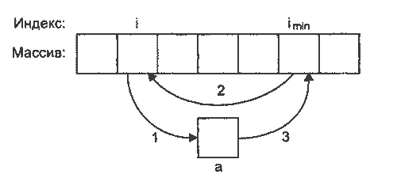

Рис. 1.9. Обмен значений двух переменных

Идентификатор массива является константным указателем на его нулевой элемент. Например, для массива из предыдущего листинга имя `b` — это то же самое, что `&b[0]`, а к `i-му` элементу массива можно обратиться, используя выражение `*(b + i)`. Можно описать указатель, присвоить ему адрес начала массива и работать с массивом через указатель. Следующий фрагмент программы копирует все элементы массива `a` в массив `b`:

```
int a[100], b[100];
int *pa = a; // или int *p = &a[0];
int *pb = b;
for(int i = 0; i < 100; i++)
    *pb++ = *pa++; // или pb[i] = pa[i];
```

Динамические массивы создают с помощью операции `new`, при этом необходимо указать тип и размерность, например:

```
int n = 100;
float *p = new float[n];
```

В этой строке создается переменная-указатель на `float`, в динамической памяти отводится непрерывная область, достаточная для размещения 100 элементов вещественного типа, и адрес ее начала записывается в указатель `p`. Динамические массивы нельзя при создании инициализировать, и они не обнуляются.

Страница 060

**Преимущество динамических массивов** состоит в том, что размерность может быть переменной, то есть объем памяти, выделяемой под массив, определяется на этапе выполнения программы. Доступ к элементам динамического массива осуществляется точно так же, как к статическим, например, к элементу номер 5 приведенного выше массива можно обратиться как `p[5]` или `*(p + 5)`.

**Альтернативный способ создания динамического массива** — использование функции `malloc` библиотеки C:

```
int n = 100;
float *q = (float*) malloc(n * sizeof(float));
```

Операция преобразования типа, записанная перед обращением к функции `malloc`, требуется потому, что функция возвращает значение указателя типа `void*`, а инициализируется указатель на `float`. Память, зарезервированная под динамический массив с помощью `new[]`, должна освобождаться оператором `delete[]`, а память, выделенная функцией `malloc` — посредством функции `free`, например:

```
delete[] p; free(q);
```

При несоответствии способов выделения и освобождения памяти результат не определён. Размерность массива в операции `delete` не указывается, но квадратные скобки обязательны.

**Многомерные массивы** задаются указанием каждого измерения в квадратных скобках, например, оператор

```
int matr[6][8];
```

задает описание двумерного массива из 6 строк и 8 столбцов. В памяти такой массив располагается в последовательных ячейках построчно. Многомерные массивы размещаются так, что при переходе к следующему элементу быстрее всего изменяется последний индекс. Для доступа к элементу многомерного массива указываются все его индексы, например, `matr[i][j]`, или более экзотическим способом: `*(matr[i] + j)` или `*(*(matr + i) + j)`. Это возможно, поскольку `matr[i]` является адресом начала `i-й` строки массива. При инициализации многомерного массива он представляется либо как массив из массивов, при этом каждый массив заключается в свои фигурные скобки (в этом случае левую размерность при описании можно не указывать), либо задается общий список элементов в том порядке, в котором элементы располагаются в памяти:

```
int mass2[][2] = {{1, 1}, {0, 2}, {1, 0}};
int mass2[3][2] = {1, 1, 0, 2, 1, 0};
```

Страница 061

```
#include <stdio.h>
int main()
{
    const int nstr = 4, nstb = 5; // размерности массива
    int b[nstr][nstb]; // описание массива
    int i, j;
    for (i = 0; i < nstr; i++) // ввод массива
        for (j = 0; j < nstb; j++) scanf("%d", &b[i][j]);
    int istr = -1, MaxKol = 0;
    for (i = 0; i < nstr; i++) // просмотр массива по строкам
    {
        int Kol = 0;
        for (j = 0; j < nstb; j++)
            if (b[i][j] == 0)
                Kol++;
        if (Kol > MaxKol)
        {
            istr = i;
            MaxKol = Kol;
        }
    }
```

```
    printf(" Исходный массив: \n");
    for (i = 0; i < nstr; i++)
    {
        for (j = 0; j < nstb; j++)
            printf("%d ", b[i][j]);
        printf("\n");
    }
    if (istr == -1)
    {
        printf("Нулевых элементов нет");
    }
    else
    {
        printf("Номер строки: %d", istr);
    }
    return 0;
}
```

Страница 062

Номер искомой строки хранится в переменной `istr`, количество нулевых элементов в текущей (`i-й`) строке — в переменной `Kol`, максимальное количество нулевых элементов — в переменной `MaxKol`. Массив просматривается по строкам, в каждой из них подсчитывается количество нулевых элементов (обратите внимание, что переменная `Kol` обнуляется перед просмотром каждой строки). Наибольшее количество и номер соответствующей строки запоминаются.

Для создания динамического многомерного массива необходимо указать в операции `new` все его размерности (самая левая размерность может быть переменной), например:

```
int nstr = 5;
int **m = (int **) new int[nstr][10];
```

Более универсальный и безопасный способ выделения памяти под двумерный массив, когда обе его размерности задаются на этапе выполнения программы, приведен ниже:

```
int nstr, nstb;
cout << " Введите количество строк и столбцов :";
cin >> nstr >> nstb;
int **a = new int *[nstr]; // 1
for(int i = 0; i < nstr; i++) // 2
    a[i] = new int[nstb]; // 3
```

В операторе 1 объявляется переменная типа «указатель на указатель на int» и выделяется память под массив указателей на строки массива (количество строк — `nstr`). В операторе 2 организуется цикл для выделения памяти под каждую строку массива. В операторе 3 каждому элементу массива указателей на строки присваивается адрес участка памяти, выделенного под строку двумерного массива. Каждая строка состоит из `nstb` элементов типа `int` (рис. 1.10).

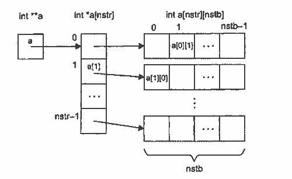

Рис. 1.10. Выделение памяти под двумерный массив

Освобождение памяти из-под массива с любым количеством измерений выполняется с помощью операции `delete[]`. Указатель на константу удалить нельзя.

**ПРИМЕЧАНИЕ** Для правильной интерпретации объявлений полезно запомнить мнемоническое правило: «суффикс привязан крепче префикса». Если при описании переменной используются одновременно префикс `*` (указатель) и суффикс `[]` (массив), то переменная интерпретируется как массив указателей, а не указатель на массив: `int *p[10];` — массив из 10 указателей на `int`.

# Строки

Строка представляет собой массив символов, заканчивающийся нуль-символом. Нуль-символ — это символ с кодом, равным 0, что записывается в виде управляющей последовательности `'\0'`. По положению нуль-символа определяется фактическая длина строки. Строку можно инициализировать строковым литералом (см. с. 20):

```
char str[10] = "Vasia";
// выделено 10 элементов с номерами от 0 до 9
// первые элементы - 'V', 'a', 's', 'i', 'a', '\0'
```

В этом примере под строку выделяется 10 байт, 5 из которых занято под символы строки, а шестой — под нуль-символ. Если строка при определении инициализируется, ее размерность можно опускать (компилятор сам выделит соответствующее количество байт):

```
char str[] = "Vasia"; // выделено и заполнено 6 байт
```

Оператор

```
char *str = "Vasia";
```

создаёт указатель на строковый литерал, которую изменять нельзя (к примеру, оператор `*str = 'M';` не допускается). Знак равенства перед строковым литералом означает инициализацию, а не присваивание. Операция присваивания одной строки другой не определена (поскольку строка является массивом) и может выполняться с помощью цикла или функций стандартной библиотеки. Библиотека предоставляет возможности копирования, сравнения, объединения строк, поиска подстроки, определения длины строки и т. д. (возможности библиотеки описаны в разделе «Функции работы со строками и символами», с. 91, и в приложении 6), а также содержит специальные функции ввода строк и отдельных символов с клавиатуры и из файла.

Страница 063

Пример. Программа запрашивает пароль не более трех раз.

```
#include <stdio.h>
#include <string.h>
int main()
{
    char s[80], passw[] = "kuku"; // passw - эталонный пароль.
    // Можно описать как *passw = "kuku";
    int i, k = 0;
    for (i = 0; !k && i < 3; i++)
    {
        printf("\nВведите пароль: ");
        gets(s); // функция ввода строки
        if (strstr(s, passw)) k = 1; // функция сравнения строк
    }
    if (k) printf("\nПароль принят");
    else printf("\nПароль не принят");
    return 0;
}
```

При работе со строками часто используются указатели.

**ВНИМАНИЕ** Распространенные ошибки при работе со строками — отсутствие нуль-символа и выход указателя при просмотре строки за ее пределы.

Рассмотрим процесс копирования строки `src` в строку `dest`. Очевидный алгоритм имеет вид:

```
char src[10], dest[10];
for (int i = 0; i <= strlen(src); i++) dest[i] = src[i];
```

Длина строки определяется с помощью функции `strlen`, которая вычисляет длину, выполняя поиск нуль-символа. Таким образом, строка фактически просматривается дважды. Более эффективным будет использовать проверку на нуль-символ непосредственно в программе. Увеличение индекса можно заменить инкрементом указателей (для этого память под строку `src` должна выделяться динамически, а также требуется определить дополнительный указатель и инициализировать его адресом начала строки `dest`):

```
#include <iostream.h>
int main()
{
    char *src = new char[10];
    char *dest = new char[10], *d = dest;
    cin >> src;
    while (*src != 0) *d++ = *src++;
    *d = 0; // завершающий нуль
    cout << dest;
    return 0;
}
```

Страница 064

В цикле производится посимвольное присваивание элементов строк с одновременной инкрементацией указателей. Результат операции присваивания — передаваемое значение, которое, собственно, и проверяется в условии цикла, поэтому можно поставить присваивание на место условия, а проверку на неравенство нулю опустить (при этом завершающий нуль копируется в цикле, и отдельного оператора для его присваивания не требуется). В результате цикл копирования строки принимает вид:

```
while (*d++ = *src++);
```

Оба способа работы со строками (через массивы или указатели) приемлемы и имеют свои плюсы и минусы, но в общем случае лучше не изобретать велосипед, а пользоваться функциями библиотеки или определённым в стандартной библиотеке C++ классом `string`, который обеспечивает индексацию, присваивание, сравнение, добавление, объединение строк и поиск подстрок, а также преобразование из С-строк, то есть массивов типа `char`, в `string`, и наоборот (строки C++ описаны в разделе «Строки» на с. 286).

**ПРИМЕЧАНИЕ**

Строки string не обязательно должны состоять из символов типа char. Это позволяет ис- пользовать любой набор символов (не только ASCII), но для произвольного набора следу- ет определить собственную операцию копирования, что может снизить эффективность работы.

# Типы данных, определяемые пользователем

В реальных задачах информация, которую требуется обрабатывать, может иметь достаточно сложную структуру. Для ее адекватного представления используются типы данных, построенные на основе простых типов данных, массивов и указателей. Язык C++ позволяет программисту определять свои типы данных и правила работы с ними. Исторически для таких типов сложилось наименование, вынесенное в название главы, хотя правильнее было бы назвать их типами, определяемыми программистом.

Страница 065

# Переименование типов (typedef)

Для того чтобы сделать программу более ясной, можно задать типу новое имя с помощью ключевого слова `typedef`:

```
typedef тип новое_имя [размерность];
```

В данном случае квадратные скобки являются элементом синтаксиса. Размерность может отсутствовать. Примеры:

```
typedef unsigned int UINT;
typedef char Msg[100];
typedef struct
{
    char fio[30];
    int date, code;
    double salary;
}
Worker;
```

Введённое таким образом имя можно использовать таким же образом, как и имена стандартных типов:

```
UINT i, j; // две переменных типа unsigned int
Msg str[10]; // массив из 10 строк по 100 символов
Worker staff[100]; // массив из 100 структур
```

Кроме задания типам с длинными описаниями более коротких псевдонимов, `typedef` используется для облегчения переносимости программ: если машинно-зависимые типы объявить с помощью операторов `typedef`, при переносе программы потребуется внести изменения только в эти операторы.

# Перечисления (enum)

При написании программ часто возникает потребность определить несколько именованных констант, для которых требуется, чтобы все они имели различные значения (при этом конкретные значения могут быть не важны). Для этого удобно воспользоваться перечисляемым типом данных, все возможные значения которого задаются списком целочисленных констант. Формат:

```
enum [имя_типа] {список_констант};
```

Имя типа задается в том случае, если в программе требуется определять переменные этого типа. Компилятор обеспечивает, чтобы эти переменные принимали значения только из списка констант. Константы должны быть целочисленными и могут инициализироваться обычным образом. При отсутствии инициализатора первая константа обнуляется, а каждой следующей присваивается на единицу большее значение, чем предыдущей:

```
enum Err {ERR_READ, ERR_WRITE, ERR_CONVERT};
Err error;
//...
switch (error)
{
    case ERR_READ:
        /* операторы */ break;
    case ERR_WRITE:
        /* операторы */ break;
    case ERR_CONVERT:
        /* операторы */ break;
}
```

Константам `ERR_READ`, `ERR_WRITE`, `ERR_CONVERT` присваиваются значения 0, 1 и 2 соответственно.

Страница 066

Другой пример:

```
enum {two = 2, three, four, ten = 10, eleven, fifty = ten + 40};
```

Константам three и four присваиваются значения 3 и 4, константе eleven - 11. Имена перечисляемых констант должны быть уникальными, а значения могут совпадать. Преимущество применения перечисления перед описанием именованных констант и директивой `#define` (см. раздел «Директива #define», с. 94) состоит в том, что связанные константы нагляднее; кроме того, компилятор при инициализации констант может выполнять проверку типов. При выполнении арифметических операций перечисления преобразуются в целые. Поскольку перечисления являются типами, определяемыми пользователем, для них можно вводить собственные операции (см. «Перегрузка операций», с. 189).

**ПРИМЕЧАНИЕ** Диапазон значений перечисления определяется количеством бит, необходимым для представления всех его значений. Любое значение целочисленного типа можно явно привести к типу перечисления, но при выходе за пределы его диапазона результат не определён.

# Структуры (struct)

В отличие от массива, все элементы которого однотипны, структура может содержать элементы разных типов. В языке C++ структура является видом класса и обладает всеми его свойствами, но во многих случаях достаточно использовать структуры так, как они определены в языке C:

```
struct [имя_типа]
{
    тип_1 элемент_1;
    тип_2 элемент_2;
    тип_n элемент_n;
} [список_описателей];
```

Элементы структуры называются полями структуры и могут иметь любой тип, кроме типа этой же структуры, но могут быть указателями на него. Если отсутствует имя типа, должен быть указан список описателей переменных, указателей или массивов. В этом случае описание структуры служит определением элементов этого списка:

```
// Определение массива структур и указателя на структуру:
struct
{
    char fio[30];
    int date, code;
    double salary;
} staff[100], *ps;
```

Страница 067

Если список отсутствует, описание структуры определяет новый тип, имя которого можно использовать в дальнейшем наряду со стандартными типами, например:

```
struct Worker
{
    char fio[30];
    int date, code;
    double salary;
}; // описание заканчивается точкой с запятой
// определение массива типа Worker и указателя на тип Worker:
Worker staff[100], *ps;
```

Имя структуры можно использовать сразу после его объявления (определение можно дать позднее) в тех случаях, когда компилятору не требуется знать размер структуры, например:

```
struct List; // объявление структуры List
struct Link
{
    List *p; // указатель на структуру List
    Link *prev, *succ; // указатели на структуру Link
};
struct List { /* определение структуры List */ };
```

Это позволяет создавать связные списки структур.

Для инициализации структуры значения ее элементов перечисляют в фигурных скобках в порядке их описания:

```
struct
{
    char fio[30];
    int date, code;
    double salary;
} worker = {"Страусенко", 31, 215, 3400.55};
```

При инициализации массивов структур следует заключать в фигурные скобки каждый элемент массива (учитывая, что многомерный массив — это массив массивов):

```
struct complex
{
    float real, im;
} compl[2][3] = {
    {{1, 1}, {1, 1}, {1, 1}}, // строка 1, то есть массив compl[0]
    {{2, 2}, {2, 2}, {2, 2}}  // строка 2, то есть массив compl[1]
};
```

Для переменных одного и того же структурного типа определена **операция присваивания**, при этом происходит поэлементное копирование. Структуру можно передавать в функцию и возвращать в качестве значения функции. Другие операции со структурами могут быть определены пользователем (см. «Перегрузка операций», с. 189). Размер структуры не обязательно равен сумме размеров ее элементов, поскольку они могут быть выровнены по границам слова.

Страница 068

**Доступ к полям структуры** выполияется с помощью операций выбора `.` (точка) при обращении к полю через имя структуры и `-›` при обращении через указатель, например.

[output not shown]

Если элементом структуры является другая структура, то доступ к ее элементам выполняется через две операции выбора:

[output not shown]

Как видно из примера, поля разных структур могут иметь одинаковые имена, поскольку у них разная область видимости. Более того, можно объявлять в одной области видимости структуру и другой объект (например, переменную или мас- сив) с одинаковыми именами, если при определении структурной переменной использовать слово struct, но не советую это делать - запутать компилятор труднее, чем себя.

# Битовые поля

**Битовые поля** - это особый вид полей структуры. Они используются для плотной упаковки данных, например, флажков типа «да/нет». Минимальная адресуемая ячейка памяти — 1 байт, а для хранения флажка достаточно одного бита. При описании битового поля после имени через двоеточие указывается длина поля в битах (целая положительная константа):

struct Options { bool centerX:1; bool centerY:1; unsigned int shadow:2; unsigned int palette:4; };

Битовые поля могут быть любого целого типа. Имя поля может отсутствовать, такие поля служат для выравнивания на аппаратную границу. Доступ к полю осуществляется обычным способом — по имени. Адрес поля получить нельзя, однако в остальном битовые поля можно использовать точно так же, как обычные поля структуры. Следует учитывать, что операции с отдельными битами реали зуются гораздо менее эффективно, чем с байтами и словами, так как компилятор должен генерировать специальные коды, и экономия памяти под переменные оборачивается увеличением объема кода программы. Размещение битовых полей в памяти зависит от компилятора и аппаратуры.

Страница 069

# Объединения (union)

Объединение (`union`) представляет собой частный случай структуры, все поля которой располагаются по одному и тому же адресу. Формат описания такой же, как у структуры, только вместо ключевого слова `struct` используется слово `union`. Длина объединения равна наибольшей из длин его полей. В каждый момент времени в переменной типа объединение хранится только одно значение, и ответственность за его правильное использование лежит на программисте. Объединения применяют для экономии памяти в тех случаях, когда известно, что больше одного поля одновременно не требуется:

```
#include <iostream.h>
int main()
{
    enum paytype {CARD, CHECK};
    paytype ptype;
    union payments
    {
        char card[25];
        long check;
    }
    info;
    /* присваивание значений info n ptype */
    switch (ptype)
    {
        case CARD: cout << "Оплата по карте: " << info.card; break;
        case CHECK: cout << "Оплата чеком: " << info.check; break;
    }
    return 0:
}
```

Объединение часто используют в качестве поля структуры, при этом в структуру удобно включить дополнительное поле, определяющее, какой именно элемент объединения используется в каждый момент. Имя объединения можно не указывать, что позволяет обращаться к его полям непосредственно:

[output not shown]

Страница 070

Объединения применяются также для разной интерпретации одного и того же битового представления (но, как правило, в этом случае лучше использовать явные операции преобразования типов). В качестве примера рассмотрим работу со структурой, содержащей битовые поля:

```
struct Options
{
    bool centerX:1;
    bool centerY:1;
    unsigned int shadow:2;
    unsigned int palette:4;
};
union
{
    unsigned char ch;
    Options bit;
}
option = {0xC4};
cout << option.bit.palette;
option.ch &= 0xF0: // наложение маски
```

По сравнению со структурами на объединения налагаются некоторые ограничения. Смысл некоторых из них станет понятен позже:

- объединение может инициализироваться только значением его первого элемента;
- объединение не может содержать битовые поля;
- объединение не может содержать виртуальные методы, конструкторы, деструкторы и операцию присваивания;
- объединение не может входить в иерархию классов.

Страница 071

# ГЛАВА 2

### Модульное программирование

Модульность - фундаментальный аспект всех успешно работающих крупных систем. Б. Страуструп

**С увеличением объема программы становится невозможным удерживать в паляти все детали**. Естественным способом борьбы со сложностью любой задачи является ее разбиение на части. В С++ задача может быть разделена на более простые и обозримые с помощью функций, после чего программу можно рассматривать в более укрупненном виде - на уровне взаимодействия функций. Это важно, поскольку человек способен помнить ограниченное количество фактов. Использование функций является первым шагом к повышению степени абстракции программы и ведет к упрощению ее структуры.

**Разделение программы на функции позволяет** также избежать избыточности кода, поскольку функцию записывают один раз, а вызывать ее на выполнение можно многократно из разных точек программы. Процесс отладки программы, содержащей функции, можно лучше структурировать. Часто используемые функции можно помещать в библиотеки. Таким образом создаются более простые в отладке и сопровождении программы.

**Следующим шагом в повышении уровня абстракции программы** является группировка функций и связанных с ними данных в отдельные файлы (модули), компилируемые раздельно. Получившиеся в результате компиляции объектные модули объединяются в исполняемую программу с помощью компоновщика. Разбиение на модули уменьшает время перекомпиляции и облегчает процесс отладки, скрывая несущественные детали за интерфейсом модуля и позволяя отлаживать программу по частям (или разными программистами).

Страница 072

Модуль содержит данные и функции их обработки. Другим модулям нежелательно иметь собственные средства обработки этих данных, они должны пользоваться для этого функциями первого модуля. Для того чтобы использовать модуль, нужно знать только его интерфейс, а не все детали его реализации. Чем более независимые модули, тем легче отлаживать программу. Это уменьшает общий объем информации, которые необходимо одновременно помнить при отладке. Разделение программы на максимально обособленные части является сложной задачей, которая должна решаться на этапе проектирования программы. *Cкрытие деталей реализации называется инкапсуляцией*. Инкапсуляция является ключевой идеей как структурного так объектно-ориентированного программирования. Примеры к капсуляции – помещение фрагмента кодов функцию и передачи всех необходимых ей данных в качестве параметров. Чтобы использовать такую функцию, требуется знать только её интерфейс, определяемый заголовком (имя, тип возвращаемого значения и тип параметров). Интерфейса модуля являются заголовки всех функций и описания доступных извне типов, переменных и констант. Описание глобальных программных объектов во всех модулях программ должно быть согласовано. Модульность в языке С++ поддерживается с помощью директив препроцессора, пространств имен, классов памяти, исключений и раздельной компиляции (строго говоря, раздельная компиляция не является элементом языка, а относится к его реализации).

# Функции

Функции используются для наведения порядка в хаосе алгоритмов. Б. Страуструп

# Объявление и определение функций

**Функция** - это именованная последовательность описаний и операторов, выполняющая какое-либо законченное действие. Функция может принимать параметры и возвращать значение. Любая программа на `С++` состоит из функций, одна из которых должна иметь имя `main` (с нее начинается выполнение программы). Функция начинает выполняться в момент вызова. Любая функция должна быть объявлена и определена. Как и для других величин, объявлений может быть несколько, а определение только одно. Объявление функции должно находиться в тексте раньше ее вызова для того, чтобы компилятор мог осуществить проверку правильности вызова. Объявление функции (прототип, заголовок, сигнатура) задает ее имя, тип возвращаемого значения и список передаваемых параметров. Определение функции содержит, кроме объявления, тело функции, представляющее собой последовательность операторов и описаний в фигурных скобках:

```
[ класс ] тип имя ([ список _параметров ])[throw ( исключения )]
{ тело функции }
```

Рассмотрим составные части определения.

**Во-первых**, с помощью необязательного модификатора класс можно явно задать область видимости функции, используя ключевые слова `extern` и `static`:

- extern - глобальная видимость во всех модулях программы (по умолчанию);
- static - видимость только в пределах модуля, в котором определена функция.

**Во-вторых.** Тип возвращаемого функцией значения может быть любым, кроме массива и функции (но может быть указателем на массив или функцию). Если функция не должна возвращать значение, указывается тип void.

**В-третьих.** Список параметров определяет величины, которые требуется передать в функцию при ее вызове. Элементы списка параметров разделяются запятыми. Для каждого параметра, передаваемого в функцию, указывается его тип и имя (в объявлении имена можно опускать).

**В четвёртых.** Об исключениях, обрабатываемых функцией, рассказывается в разделе «Список исключений функции», с. 227.

Страница 073

Пример функции, возвращающей сумму двух целых величин:

```
#include <iostream.h>
int sum(int a, int b); // объявление функции
int main()
{
    int a = 2, b = 3, c, d;
    c = sum(a, b); // вызов функции
    cin >> d;
    cout << sum(c, d);// вызов Функции
    return 0;
}
// определение функции
int sum(int a, int b)
{
    return (a + b);
}
```

Страница 074

Пример функции, выводящей на экран поля переданцой ей структуры:

[output not shown]

Все величины, описанные внутри функции, а также ее параметры, являются локальными. Областью их действия является функция. При вызове функции, как и при входе в любой блок, в стеке выделяется память под локальные автоматические переменные. Кроме того, в стеке сохраняется содержимое регистров процессора на момент, предшествующий вызову функции, и адрес возврата из функции для того, чтобы при выходе из нее можно было продолжать выполнение вызывающей функции. При выходе из функции соответствующий участок стека освобождается, поэтому значения локальных переменных между вызовами одной и той же функции не сохраняются. Если этого требуется избежать, при объявлении локальных переменных используется модификатор `static`:

[output not shown]

Страница 075

Статическая переменная `n` размещается в сегменте данных и инициализируется один раз при первом выполнении оператора, содержащего ее определение. Автоматическая переменная `m` инициализируется при каждом входе в функцию. Автоматическая переменная `p` инициализируется при каждом входе в блок цикла. Программа выведет на экран:

| --- | --- | --- |
| --- | --- | --- |
| n | m | p |
| 0 | 0 | 0 |
| 1 | 1 | 0 |
| 2 | 2 | 0 |
| n | m | p |
| 3 | 0 | 0 |
| 4 | 1 | 0 |

При совместной работе функции должны обмениваться информацией. Это можно осуществить с помощью глобальных переменных, через параметры и через возвращаемое функцией значение.

# Глобальные переменные

Глобальные переменные видны во всех функциях, где не описаны локальные переменные с теми же именами, поэтому использовать их для передачи данных между функциями очень легко. Тем не менее это не рекомендуется, поскольку затрудняет отладку программы и препятствует помещению функций в библиотеки общего пользования. Нужно стремиться к тому, чтобы функции были максимально независимы, а их интерфейс полностью определялся прототипом функции.

# Возвращаемое значение

Механизм возврата из функции в вызвавшую ее функцию реализуется оператором

```
return [ выражение ];
```

Примеры:

```
int f1() {return 1;} // правильно
void f2() {return 1;} // неправильно, f2 не должна возвращать значение
double f3() {return 1;} // правильно, 1 преобразуется к типу double
```

Страница 076

**ВНИМАНИЕ** Нельзя возвращать из функции указатель на локальную переменную, поскольку память, выделенная локальным переменным при входе в функцию, освобождается после возврата из нее. Пример:

```
int* f()
{
    int a = 5:
    return &a; // нельзя!
}
```

# Параметры функции

Механизм параметров является основным способом обмена информацией между вызываемой и вызывающей функциями. Параметры, перечисленные в заголовке описания функции, называются формальными параметрами, или просто параметрами, а записанные в операторе вызова функции — фактическими параметрами, или аргументами. При вызове функции в первую очередь вычисляются выражения, стоящие на месте аргументов; затем в стеке выделяется память под формальные параметры функции в соответствии с их типом, и каждому из них присваивается значение соответствующего аргумента. При этом проверяется соответствие типов и при необходимости выполняются их преобразования. При несоответствии типов выдается диагностическое сообщение. Существует два способа передачи параметров в функцию: по значению и по адресу. При передаче по значению в стек заносятся копии значений аргументов, и операторы функции работают с этими копиями. Доступа к исходным значениям параметров у функции нет, а, следовательно, нет и возможности их изменить.

При передаче по адресу в стек заносятся копии адресов аргументов, а функция осуществляет доступ к ячейкам памяти по этим адресам и может изменить исходные значения аргументов:

```
#include <iostream.h>
void f(int i, int* j, int& k);
int main()
{
    int i = 1, j = 2, k= 3;
    cout << "i j k\n";
    cout << i << ' ' << j << ' ' << k << '\n';
    f(i, &j, k);
    cout << i << ' ' << j << ' ' << k;
    return 0;
}
void f(int i, int* j, int& k)
{
    i++;
    (*j)++;
    k++;
}
```

Страница 077

Результат работы программы:

| --- | --- | --- |
| --- | --- | --- |
| i | j | k |
| 1 | 2 | 3 |
| 1 | 3 | 4 |

**Первый параметр (`i`)** передается по значению. Его изменение в функции не влияет на исходное значение. Второй параметр (`j`) передается по адресу с помощью указателя, при этом для передачи в функцию адреса фактического параметра используется операция взятия адреса, а для получения его значения в функции требуется операция разыменования. Третий параметр (`k`) передается по адресу с помощью ссылки. __При передаче по___ ссылке в функцию передается адрес указанного при вызове параметра, а внутри функции все обращения к параметру неявно разыменовываются. Поэтому использование ссылок вместо указателей улучшает читаемость программы, избавляя от необходимости применять операции получения адреса и разыменования. Использование ссылок вместо передачи по значению более эффективно, поскольку не требует копирования параметров, что имеет значение при передаче структур данных большого объема.

Если требуется запретить изменение параметра внутри функции, используется модификатор `const`:

```
int f(const char*);
char* t(char* a, const int* b);
```

**СОВЕТ** Рекомендуется указывать `const` перед всеми параметрами, изменение которых в функции не предусмотрено. Это облегчает отладку больших программ, так как по заголовку функции можно сделать вывод о том, какие величины в ней изменяются, а какие нет. Кроме того, на место параметра типа `const&` может передаваться константа, а для переменной при необходимости выполняются преобразования типа.

Таким образом, исходные данные, которые не должны изменяться в функции, предпочтительнее передавать ей с помощью константных ссылок. По умолчанию параметры любого типа, кроме массива и функции (например, вещественного, структурного, перечисление, объединение, указатель), передаются в функцию по значению.

Если размерность массива является константой, проблем не возникает, поскольку можно указать ее и при описании формального параметра, и в качестве границы циклов при обработке массива внутри функции.

Страница 078